[figure not shown]

# WELCOME!

Welcome to "RFM Customer Segmentation & Cohort Analysis Project". This is the first project of the Capstone Project Series, which consists of 4 different project that contain different scenarios.

This is a project which you will learn what is RFM? And how to apply RFM Analysis and Customer Segmentation using K-Means Clustering. Also you will improve your Data Cleaning, Data Visualization and Exploratory Data Analysis capabilities. On the other hand you will create Cohort and Conduct Cohort Analysis.

Before diving into the project, please take a look at the determines and project structure.

- **NOTE:** This tutorial assumes that you already know the basics of coding in Python and are familiar with the theory behind K-Means Clustering.

# #Determines

Using the [Online Retail dataset](https://archive.ics.uci.edu/ml/datasets/Online+Retail) from the UCI Machine Learning Repository for exploratory data analysis, *Customer Segmentation*, *RFM Analysis*, *K-Means Clustering* and *Cohort Analysis*.

This is a transnational data set which contains all the transactions occurring between 01/12/2010 and 09/12/2011 for a UK-based and registered non-store online retail. The company mainly sells unique all-occasion gifts. Many customers of the company are wholesalers.

Feature Information:

**InvoiceNo**: Invoice number. *Nominal*, a 6-digit integral number uniquely assigned to each transaction. If this code starts with letter 'c', it indicates a cancellation.  
**StockCode**: Product (item) code. *Nominal*, a 5-digit integral number uniquely assigned to each distinct product.  
**Description**: Product (item) name. *Nominal*.  
**Quantity**: The quantities of each product (item) per transaction. *Numeric*.  
**InvoiceDate**: Invoice Date and time. *Numeric*, the day and time when each transaction was generated.  
**UnitPrice**: Unit price. *Numeric*, Product price per unit in sterling.  
**CustomerID**: Customer number. *Nominal*, a 5-digit integral number uniquely assigned to each customer.  
**Country**: Country name. *Nominal*, the name of the country where each customer resides.

First of all, to observe the structure of the data and missing values, you can use exploratory data analysis and data visualization techniques.

You must do descriptive analysis. Because you must understand the relationship of the features to each other and clear the noise and missing values in the data. After that, the data set will be ready for RFM analysis.

Before starting the RFM Analysis, you will be asked to do some analysis regarding the distribution of *Orders*, *Customers* and *Countries*. These analyzes will help the company develop its sales policies and contribute to the correct use of resources.

You will notice that the UK not only has the most sales revenue, but also the most customers. So you will continue to analyze only UK transactions in the next RFM Analysis, Customer Segmentation and K-Means Clustering topics.

Next, you will begin RFM Analysis, a customer segmentation technique based on customers' past purchasing behavior.

By using RFM Analysis, you can enable companies to develop different approaches to different customer segments so that they can get to know their customers better, observe trends better, and increase customer retention and sales revenues.

You will calculate the Recency, Frequency and Monetary values of the customers in the RFM Analysis you will make using the data consisting of UK transactions. Ultimately, you have to create an RFM table containing these values.

In the Customer Segmentation section, you will create an RFM Segmentation Table where you segment your customers by using the RFM table. For example, you can label the best customer as "Big Spenders" and the lost customer as "Lost Customer".

We will segment the customers ourselves based on their recency, frequency, and monetary values. But can an **unsupervised learning** model do this better for us? You will use the K-Means algorithm to find the answer to this question. Then you will compare the classification made by the algorithm with the classification you have made yourself.

Before applying K-Means Clustering, you should do data pre-processing. In this context, it will be useful to examine feature correlations and distributions. In addition, the data you apply for K-Means should be normalized.

On the other hand, you should inform the K-means algorithm about the number of clusters it will predict. You will also try the *Elbow method* and *Silhouette Analysis* to find the optimum number of clusters.

After the above operations, you will have made cluster estimation with K-Means. You should visualize the cluster distribution by using a scatter plot. You can observe the properties of the resulting clusters with the help of the boxplot. Thus you will be able to tag clusters and interpret results.

Finally, you will do Cohort Analysis with the data you used at the beginning, regardless of the analysis you have done before. Cohort analysis is a subset of behavioral analytics that takes the user data and breaks them into related groups for analysis. This analysis can further be used to do customer segmentation and track metrics like retention, churn, and lifetime value.

# #Project Structures

- Data Cleaning & Exploratory Data Analysis
- RFM Analysis
- Customer Segmentation
- Applying K-Means Clustering
- Create Cohort and Conduct Cohort Analysis

# #Tasks

#### 1. Data Cleaning & Exploratory Data Analysis

- Import Modules, Load Data & Data Review
- Follow the Steps Below

  *i. Take a look at relationships between InvoiceNo, Quantity and UnitPrice columns.*

  *ii. What does the letter "C" in the invoiceno column mean?*

  *iii. Handling Missing Values*

  *iv. Clean the Data from the Noise and Missing Values*

  *v. Explore the Orders*

  *vi. Explore Customers by Country*

  *vii. Explore the UK Market*

#### 2. RFM Analysis

- Follow the steps below

  *i. Import Libraries*

  *ii. Review "df_uk" DataFrame (the df_uk what you create at the end of the Task 1)*

  *iii. Calculate Recency*

  *iv. Calculate Frequency*

  *v. Calculate Monetary Values*

  *vi. Create RFM Table*

#### 3. Customer Segmentation with RFM Scores

- Calculate RFM Scoring

  *i. Creating the RFM Segmentation Table*
- Plot RFM Segments

#### 4. Applying K-Means Clustering

- Data Pre-Processing and Exploring

  *i. Define and Plot Feature Correlations*

  *ii. Visualize Feature Distributions*

  *iii. Data Normalization*
- K-Means Implementation

  *i. Define Optimal Cluster Number (K) by using "Elbow Method" and "Silhouette Analysis"*

  *ii. Visualize the Clusters*

  *iii. Assign the label*

  *iv. Conclusion*

#### 5. Create Cohort and Conduct Cohort Analysis

- Future Engineering

  *i. Extract the Month of the Purchase*

  *ii. Calculating time offset in Months i.e. Cohort Index*
- Create 1st Cohort: User Number & Retention Rate

  *i. Pivot Cohort and Cohort Retention*

  *ii. Visualize analysis of cohort 1 using seaborn and matplotlib*
- Create 2nd Cohort: Average Quantity Sold

  *i. Pivot Cohort and Cohort Retention*

  *ii. Visualize analysis of cohort 2 using seaborn and matplotlib*
- Create 3rd Cohort: Average Sales

  *i. Pivot Cohort and Cohort Retention*

  *ii. Visualize analysis of cohort 3 using seaborn and matplotlib*
- **Note: There may be sub-tasks associated with each task, you will see them in order during the course of the work.**

# 1. Data Cleaning & Exploratory Data Analysis

## Import Modules, Load Data & Data Review

```python
import numpy as np
import pandas as pd

import matplotlib.pyplot as plt
import seaborn as sns
import os
from sklearn.preprocessing import MinMaxScaler
```

```python
df = pd.read_excel("Online Retail.xlsx")
df
```

|  | InvoiceNo | StockCode | Description | Quantity | InvoiceDate | UnitPrice | CustomerID | Country |
| --- | --- | --- | --- | --- | --- | --- | --- | --- |
| 0 | 536365 | 85123A | WHITE HANGING HEART T-LIGHT HOLDER | 6 | 2010-12-01 08:26:00 | 2.5 | 17,850.0 | United Kingdom |
| 1 | 536365 | 71053 | WHITE METAL LANTERN | 6 | 2010-12-01 08:26:00 | 3.4 | 17,850.0 | United Kingdom |
| 2 | 536365 | 84406B | CREAM CUPID HEARTS COAT HANGER | 8 | 2010-12-01 08:26:00 | 2.8 | 17,850.0 | United Kingdom |
| 3 | 536365 | 84029G | KNITTED UNION FLAG HOT WATER BOTTLE | 6 | 2010-12-01 08:26:00 | 3.4 | 17,850.0 | United Kingdom |
| 4 | 536365 | 84029E | RED WOOLLY HOTTIE WHITE HEART. | 6 | 2010-12-01 08:26:00 | 3.4 | 17,850.0 | United Kingdom |
| ... | ... | ... | ... | ... | ... | ... | ... | ... |
| 541904 | 581587 | 22613 | PACK OF 20 SPACEBOY NAPKINS | 12 | 2011-12-09 12:50:00 | 0.8 | 12,680.0 | France |
| 541905 | 581587 | 22899 | CHILDREN'S APRON DOLLY GIRL | 6 | 2011-12-09 12:50:00 | 2.1 | 12,680.0 | France |
| 541906 | 581587 | 23254 | CHILDRENS CUTLERY DOLLY GIRL | 4 | 2011-12-09 12:50:00 | 4.2 | 12,680.0 | France |
| 541907 | 581587 | 23255 | CHILDRENS CUTLERY CIRCUS PARADE | 4 | 2011-12-09 12:50:00 | 4.2 | 12,680.0 | France |
| 541908 | 581587 | 22138 | BAKING SET 9 PIECE RETROSPOT | 3 | 2011-12-09 12:50:00 | 5.0 | 12,680.0 | France |

541909 rows × 8 columns

```python
df.columns
```

```
Index(['InvoiceNo', 'StockCode', 'Description', 'Quantity', 'InvoiceDate',
       'UnitPrice', 'CustomerID', 'Country'],
      dtype='object')
```

```python
df.info()
```

```
<class 'pandas.core.frame.DataFrame'>
RangeIndex: 541909 entries, 0 to 541908
Data columns (total 8 columns):
 #   Column       Non-Null Count   Dtype
---  ------       --------------   -----
 0   InvoiceNo    541909 non-null  object
 1   StockCode    541909 non-null  object
 2   Description  540455 non-null  object
 3   Quantity     541909 non-null  int64
 4   InvoiceDate  541909 non-null  datetime64[ns]
 5   UnitPrice    541909 non-null  float64
 6   CustomerID   406829 non-null  float64
 7   Country      541909 non-null  object
dtypes: datetime64[ns](1), float64(2), int64(1), object(4)
memory usage: 33.1+ MB
```

```python
df.isnull().sum()
```

```
InvoiceNo           0
StockCode           0
Description      1454
Quantity            0
InvoiceDate         0
UnitPrice           0
CustomerID     135080
Country             0
dtype: int64
```

```python
(df.isnull().sum()/df.shape[0])*100
```

```
InvoiceNo      0.0
StockCode      0.0
Description    0.3
Quantity       0.0
InvoiceDate    0.0
UnitPrice      0.0
CustomerID    24.9
Country        0.0
dtype: float64
```

```python
df.Description.value_counts(dropna=False)
```

```
WHITE HANGING HEART T-LIGHT HOLDER     2369
REGENCY CAKESTAND 3 TIER               2200
JUMBO BAG RED RETROSPOT                2159
PARTY BUNTING                          1727
LUNCH BAG RED RETROSPOT                1638
                                       ...
WOOLLY HAT SOCK GLOVE ADVENT STRING       1
ANT SILVER TURQUOISE BOUDICCA RING        1
GREEN PENDANT SHELL NECKLACE              1
SWEETHEART KEY CABINET                    1
???lost                                   1
Name: Description, Length: 4224, dtype: int64
```

```python
df.CustomerID.value_counts(dropna=False)
```

```
nan         135080
17,841.0      7983
14,911.0      5903
14,096.0      5128
12,748.0      4642
             ...
16,148.0         1
16,144.0         1
16,138.0         1
16,093.0         1
17,948.0         1
Name: CustomerID, Length: 4373, dtype: int64
```

```python
df.InvoiceNo.value_counts()
```

```
573585     1114
581219      749
581492      731
580729      721
558475      705
           ...
561475        1
C580698       1
561392        1
561386        1
C552012       1
Name: InvoiceNo, Length: 25900, dtype: int64
```

*25% of CustomerID Column is null and 0.26% of Description Column(Product Name) is null*

```python
df.describe().T
```

|  | count | mean | std | min | 25% | 50% | 75% | max |
| --- | --- | --- | --- | --- | --- | --- | --- | --- |
| Quantity | 541,909.0 | 9.6 | 218.1 | -80,995.0 | 1.0 | 3.0 | 10.0 | 80,995.0 |
| UnitPrice | 541,909.0 | 4.6 | 96.8 | -11,062.1 | 1.2 | 2.1 | 4.1 | 38,970.0 |
| CustomerID | 406,829.0 | 15,287.7 | 1,713.6 | 12,346.0 | 13,953.0 | 15,152.0 | 16,791.0 | 18,287.0 |

*Negative Quantity and UnitPrice should be handled.*

### i. Take a look at relationships between InvoiceNo, Quantity and UnitPrice columns.

```python
df[["InvoiceNo", "Quantity", "UnitPrice"]]
```

|  | InvoiceNo | Quantity | UnitPrice |
| --- | --- | --- | --- |
| 0 | 536365 | 6 | 2.5 |
| 1 | 536365 | 6 | 3.4 |
| 2 | 536365 | 8 | 2.8 |
| 3 | 536365 | 6 | 3.4 |
| 4 | 536365 | 6 | 3.4 |
| ... | ... | ... | ... |
| 541904 | 581587 | 12 | 0.8 |
| 541905 | 581587 | 6 | 2.1 |
| 541906 | 581587 | 4 | 4.2 |
| 541907 | 581587 | 4 | 4.2 |
| 541908 | 581587 | 3 | 5.0 |

541909 rows × 3 columns

```python
df[["InvoiceNo", "Quantity", "UnitPrice"]].sort_values(by="UnitPrice").head(5)
```

|  | InvoiceNo | Quantity | UnitPrice |
| --- | --- | --- | --- |
| 299984 | A563187 | 1 | -11,062.1 |
| 299983 | A563186 | 1 | -11,062.1 |
| 40984 | 539750 | 1 | 0.0 |
| 52217 | 540696 | 1 | 0.0 |
| 52262 | 540699 | 1000 | 0.0 |

```python
df[["InvoiceNo", "Quantity", "UnitPrice"]].sort_values(by="Quantity").head(10625)
```

|  | InvoiceNo | Quantity | UnitPrice |
| --- | --- | --- | --- |
| 540422 | C581484 | -80995 | 2.1 |
| 61624 | C541433 | -74215 | 1.0 |
| 225529 | 556690 | -9600 | 0.0 |
| 225530 | 556691 | -9600 | 0.0 |
| 4287 | C536757 | -9360 | 0.0 |
| ... | ... | ... | ... |
| 363775 | C568581 | -1 | 4.0 |
| 449989 | C575150 | -1 | 1.2 |
| 407299 | C571856 | -1 | 3.0 |
| 52435 | C540793 | -1 | 3.0 |
| 150706 | 549524 | 1 | 16.6 |

10625 rows × 3 columns

We see that there are negative values in the Quantity and UnitPrice columns. These are possibly canceled and returned orders. Let's check it out.

### ii. What does the letter "C" in the InvoiceNo column mean?

```python
#  Test if the start of each string element matches a pattern.
bool_series = df.InvoiceNo.str.startswith("C", na = False)
df[bool_series]
```

|  | InvoiceNo | StockCode | Description | Quantity | InvoiceDate | UnitPrice | CustomerID | Country |
| --- | --- | --- | --- | --- | --- | --- | --- | --- |
| 141 | C536379 | D | Discount | -1 | 2010-12-01 09:41:00 | 27.5 | 14,527.0 | United Kingdom |
| 154 | C536383 | 35004C | SET OF 3 COLOURED FLYING DUCKS | -1 | 2010-12-01 09:49:00 | 4.7 | 15,311.0 | United Kingdom |
| 235 | C536391 | 22556 | PLASTERS IN TIN CIRCUS PARADE | -12 | 2010-12-01 10:24:00 | 1.6 | 17,548.0 | United Kingdom |
| 236 | C536391 | 21984 | PACK OF 12 PINK PAISLEY TISSUES | -24 | 2010-12-01 10:24:00 | 0.3 | 17,548.0 | United Kingdom |
| 237 | C536391 | 21983 | PACK OF 12 BLUE PAISLEY TISSUES | -24 | 2010-12-01 10:24:00 | 0.3 | 17,548.0 | United Kingdom |
| ... | ... | ... | ... | ... | ... | ... | ... | ... |
| 540449 | C581490 | 23144 | ZINC T-LIGHT HOLDER STARS SMALL | -11 | 2011-12-09 09:57:00 | 0.8 | 14,397.0 | United Kingdom |
| 541541 | C581499 | M | Manual | -1 | 2011-12-09 10:28:00 | 224.7 | 15,498.0 | United Kingdom |
| 541715 | C581568 | 21258 | VICTORIAN SEWING BOX LARGE | -5 | 2011-12-09 11:57:00 | 10.9 | 15,311.0 | United Kingdom |
| 541716 | C581569 | 84978 | HANGING HEART JAR T-LIGHT HOLDER | -1 | 2011-12-09 11:58:00 | 1.2 | 17,315.0 | United Kingdom |
| 541717 | C581569 | 20979 | 36 PENCILS TUBE RED RETROSPOT | -5 | 2011-12-09 11:58:00 | 1.2 | 17,315.0 | United Kingdom |

9288 rows × 8 columns

If the invoice number starts with the letter "C", it means the order was cancelled. Or those who abandon their order.

```python
df[bool_series][df.Quantity > 0]
```

|  | InvoiceNo | StockCode | Description | Quantity | InvoiceDate | UnitPrice | CustomerID | Country |
| --- | --- | --- | --- | --- | --- | --- | --- | --- |

*Nothing returned.*

```python
df[bool_series==False][df.Quantity < 0]
```

|  | InvoiceNo | StockCode | Description | Quantity | InvoiceDate | UnitPrice | CustomerID | Country |
| --- | --- | --- | --- | --- | --- | --- | --- | --- |
| 2406 | 536589 | 21777 | NaN | -10 | 2010-12-01 16:50:00 | 0.0 | nan | United Kingdom |
| 4347 | 536764 | 84952C | NaN | -38 | 2010-12-02 14:42:00 | 0.0 | nan | United Kingdom |
| 7188 | 536996 | 22712 | NaN | -20 | 2010-12-03 15:30:00 | 0.0 | nan | United Kingdom |
| 7189 | 536997 | 22028 | NaN | -20 | 2010-12-03 15:30:00 | 0.0 | nan | United Kingdom |
| 7190 | 536998 | 85067 | NaN | -6 | 2010-12-03 15:30:00 | 0.0 | nan | United Kingdom |
| ... | ... | ... | ... | ... | ... | ... | ... | ... |
| 535333 | 581210 | 23395 | check | -26 | 2011-12-07 18:36:00 | 0.0 | nan | United Kingdom |
| 535335 | 581212 | 22578 | lost | -1050 | 2011-12-07 18:38:00 | 0.0 | nan | United Kingdom |
| 535336 | 581213 | 22576 | check | -30 | 2011-12-07 18:38:00 | 0.0 | nan | United Kingdom |
| 536908 | 581226 | 23090 | missing | -338 | 2011-12-08 09:56:00 | 0.0 | nan | United Kingdom |
| 538919 | 581422 | 23169 | smashed | -235 | 2011-12-08 15:24:00 | 0.0 | nan | United Kingdom |

1336 rows × 8 columns

*We have 1336 non-canceled but negative quantity orders, 9288 canceled and negative quantity orders. Total: 10624 negative quantity orders.*

```python
(df[bool_series].shape[0]/df.shape[0])*100
```

```
1.7139409015166756
```

*About 1.7% of the orders were canceled*

```python
df.sort_values(by="UnitPrice").head(5)
```

|  | InvoiceNo | StockCode | Description | Quantity | InvoiceDate | UnitPrice | CustomerID | Country |
| --- | --- | --- | --- | --- | --- | --- | --- | --- |
| 299984 | A563187 | B | Adjust bad debt | 1 | 2011-08-12 14:52:00 | -11,062.1 | nan | United Kingdom |
| 299983 | A563186 | B | Adjust bad debt | 1 | 2011-08-12 14:51:00 | -11,062.1 | nan | United Kingdom |
| 40984 | 539750 | 22652 | TRAVEL SEWING KIT | 1 | 2010-12-21 15:40:00 | 0.0 | nan | United Kingdom |
| 52217 | 540696 | 84562A | NaN | 1 | 2011-01-11 09:14:00 | 0.0 | nan | United Kingdom |
| 52262 | 540699 | POST | NaN | 1000 | 2011-01-11 09:32:00 | 0.0 | nan | United Kingdom |

*Negative Unit Price means that these are bad debt and have specific InvoiceNo starting with letter "A". We have only two records. We can check the same InvoiceNo*

```python
bool_series_A = df.InvoiceNo.str.startswith("A", na = False)
df[bool_series_A]
```

|  | InvoiceNo | StockCode | Description | Quantity | InvoiceDate | UnitPrice | CustomerID | Country |
| --- | --- | --- | --- | --- | --- | --- | --- | --- |
| 299982 | A563185 | B | Adjust bad debt | 1 | 2011-08-12 14:50:00 | 11,062.1 | nan | United Kingdom |
| 299983 | A563186 | B | Adjust bad debt | 1 | 2011-08-12 14:51:00 | -11,062.1 | nan | United Kingdom |
| 299984 | A563187 | B | Adjust bad debt | 1 | 2011-08-12 14:52:00 | -11,062.1 | nan | United Kingdom |

**_We have only 3 values, all of them can be deleted while their counts are very small and we dont know the customers*ID.***

### iii. Handling Missing Values

```python
df.CustomerID.isnull().sum()
```

```
135080
```

Since the customer ID's are missing, lets assume these orders were not made by the customers already in the data set because those customers already have ID's.

We also don't want to assign these orders to those customers because this would alter the insights we draw from the data.

```python
#  We want to see description column values of canceled Orders
df[bool_series]["Description"]
```

```
141                               Discount
154        SET OF 3 COLOURED  FLYING DUCKS
235         PLASTERS IN TIN CIRCUS PARADE
236       PACK OF 12 PINK PAISLEY TISSUES
237       PACK OF 12 BLUE PAISLEY TISSUES
                        ...
540449     ZINC T-LIGHT HOLDER STARS SMALL
541541                              Manual
541715          VICTORIAN SEWING BOX LARGE
541716    HANGING HEART JAR T-LIGHT HOLDER
541717       36 PENCILS TUBE RED RETROSPOT
Name: Description, Length: 9288, dtype: object
```

```python
df[df.CustomerID.isnull()]
```

|  | InvoiceNo | StockCode | Description | Quantity | InvoiceDate | UnitPrice | CustomerID | Country |
| --- | --- | --- | --- | --- | --- | --- | --- | --- |
| 622 | 536414 | 22139 | NaN | 56 | 2010-12-01 11:52:00 | 0.0 | nan | United Kingdom |
| 1443 | 536544 | 21773 | DECORATIVE ROSE BATHROOM BOTTLE | 1 | 2010-12-01 14:32:00 | 2.5 | nan | United Kingdom |
| 1444 | 536544 | 21774 | DECORATIVE CATS BATHROOM BOTTLE | 2 | 2010-12-01 14:32:00 | 2.5 | nan | United Kingdom |
| 1445 | 536544 | 21786 | POLKADOT RAIN HAT | 4 | 2010-12-01 14:32:00 | 0.8 | nan | United Kingdom |
| 1446 | 536544 | 21787 | RAIN PONCHO RETROSPOT | 2 | 2010-12-01 14:32:00 | 1.7 | nan | United Kingdom |
| ... | ... | ... | ... | ... | ... | ... | ... | ... |
| 541536 | 581498 | 85099B | JUMBO BAG RED RETROSPOT | 5 | 2011-12-09 10:26:00 | 4.1 | nan | United Kingdom |
| 541537 | 581498 | 85099C | JUMBO BAG BAROQUE BLACK WHITE | 4 | 2011-12-09 10:26:00 | 4.1 | nan | United Kingdom |
| 541538 | 581498 | 85150 | LADIES & GENTLEMEN METAL SIGN | 1 | 2011-12-09 10:26:00 | 5.0 | nan | United Kingdom |
| 541539 | 581498 | 85174 | S/4 CACTI CANDLES | 1 | 2011-12-09 10:26:00 | 10.8 | nan | United Kingdom |
| 541540 | 581498 | DOT | DOTCOM POSTAGE | 1 | 2011-12-09 10:26:00 | 1,714.2 | nan | United Kingdom |

135080 rows × 8 columns

_Result:

```
1. CustomerID NaN values (135080 records).<br>
2. Negative Unit Price (3 records)<br>
3. Canceled Negative Quantity Orders (9288 records)<br>
4. Non_Canceled Negative Quantity Orders (1336 records)_
```

### iv. Clean the Data from the Noise and Missing Values

```python
# CustomerID (135080 records are cleaned)
df1 = df[df.CustomerID.notna()]
df1.shape
```

```
(406829, 8)
```

```python
# 3 Negative Unit Price values are cleaned as well
bool_series_Anew = df1.InvoiceNo.str.startswith("A", na = False)
df1[bool_series_Anew]
```

|  | InvoiceNo | StockCode | Description | Quantity | InvoiceDate | UnitPrice | CustomerID | Country |
| --- | --- | --- | --- | --- | --- | --- | --- | --- |

```python
# 8905 Canceled Negative Quantity Orders will be deleted in the DataSet in order for following analysis
bool_series_new = df1.InvoiceNo.str.startswith("C", na = False)
df1[bool_series_new]
```

|  | InvoiceNo | StockCode | Description | Quantity | InvoiceDate | UnitPrice | CustomerID | Country |
| --- | --- | --- | --- | --- | --- | --- | --- | --- |
| 141 | C536379 | D | Discount | -1 | 2010-12-01 09:41:00 | 27.5 | 14,527.0 | United Kingdom |
| 154 | C536383 | 35004C | SET OF 3 COLOURED FLYING DUCKS | -1 | 2010-12-01 09:49:00 | 4.7 | 15,311.0 | United Kingdom |
| 235 | C536391 | 22556 | PLASTERS IN TIN CIRCUS PARADE | -12 | 2010-12-01 10:24:00 | 1.6 | 17,548.0 | United Kingdom |
| 236 | C536391 | 21984 | PACK OF 12 PINK PAISLEY TISSUES | -24 | 2010-12-01 10:24:00 | 0.3 | 17,548.0 | United Kingdom |
| 237 | C536391 | 21983 | PACK OF 12 BLUE PAISLEY TISSUES | -24 | 2010-12-01 10:24:00 | 0.3 | 17,548.0 | United Kingdom |
| ... | ... | ... | ... | ... | ... | ... | ... | ... |
| 540449 | C581490 | 23144 | ZINC T-LIGHT HOLDER STARS SMALL | -11 | 2011-12-09 09:57:00 | 0.8 | 14,397.0 | United Kingdom |
| 541541 | C581499 | M | Manual | -1 | 2011-12-09 10:28:00 | 224.7 | 15,498.0 | United Kingdom |
| 541715 | C581568 | 21258 | VICTORIAN SEWING BOX LARGE | -5 | 2011-12-09 11:57:00 | 10.9 | 15,311.0 | United Kingdom |
| 541716 | C581569 | 84978 | HANGING HEART JAR T-LIGHT HOLDER | -1 | 2011-12-09 11:58:00 | 1.2 | 17,315.0 | United Kingdom |
| 541717 | C581569 | 20979 | 36 PENCILS TUBE RED RETROSPOT | -5 | 2011-12-09 11:58:00 | 1.2 | 17,315.0 | United Kingdom |

8905 rows × 8 columns

```python
#  1336 Non_Canceled Negative Quantity Orders are also cleaned while they dont have CustomerID.
df1[bool_series_new == False][df1.Quantity < 0]
```

|  | InvoiceNo | StockCode | Description | Quantity | InvoiceDate | UnitPrice | CustomerID | Country |
| --- | --- | --- | --- | --- | --- | --- | --- | --- |

```python
inx = df1.loc[df1["Quantity"] < 0].index
df1.drop(inx, inplace=True)
df1.loc[df1["Quantity"] < 0]
```

|  | InvoiceNo | StockCode | Description | Quantity | InvoiceDate | UnitPrice | CustomerID | Country |
| --- | --- | --- | --- | --- | --- | --- | --- | --- |

```python
df1.info()
```

```
<class 'pandas.core.frame.DataFrame'>
Int64Index: 397924 entries, 0 to 541908
Data columns (total 8 columns):
 #   Column       Non-Null Count   Dtype
---  ------       --------------   -----
 0   InvoiceNo    397924 non-null  object
 1   StockCode    397924 non-null  object
 2   Description  397924 non-null  object
 3   Quantity     397924 non-null  int64
 4   InvoiceDate  397924 non-null  datetime64[ns]
 5   UnitPrice    397924 non-null  float64
 6   CustomerID   397924 non-null  float64
 7   Country      397924 non-null  object
dtypes: datetime64[ns](1), float64(2), int64(1), object(4)
memory usage: 27.3+ MB
```

##### Duplicates

```python
#Lets see if there are any duplicated rows
df1[df1.duplicated(keep=False)]
```

|  | InvoiceNo | StockCode | Description | Quantity | InvoiceDate | UnitPrice | CustomerID | Country |
| --- | --- | --- | --- | --- | --- | --- | --- | --- |
| 485 | 536409 | 22111 | SCOTTIE DOG HOT WATER BOTTLE | 1 | 2010-12-01 11:45:00 | 5.0 | 17,908.0 | United Kingdom |
| 489 | 536409 | 22866 | HAND WARMER SCOTTY DOG DESIGN | 1 | 2010-12-01 11:45:00 | 2.1 | 17,908.0 | United Kingdom |
| 494 | 536409 | 21866 | UNION JACK FLAG LUGGAGE TAG | 1 | 2010-12-01 11:45:00 | 1.2 | 17,908.0 | United Kingdom |
| 517 | 536409 | 21866 | UNION JACK FLAG LUGGAGE TAG | 1 | 2010-12-01 11:45:00 | 1.2 | 17,908.0 | United Kingdom |
| 521 | 536409 | 22900 | SET 2 TEA TOWELS I LOVE LONDON | 1 | 2010-12-01 11:45:00 | 3.0 | 17,908.0 | United Kingdom |
| ... | ... | ... | ... | ... | ... | ... | ... | ... |
| 541675 | 581538 | 22068 | BLACK PIRATE TREASURE CHEST | 1 | 2011-12-09 11:34:00 | 0.4 | 14,446.0 | United Kingdom |
| 541689 | 581538 | 23318 | BOX OF 6 MINI VINTAGE CRACKERS | 1 | 2011-12-09 11:34:00 | 2.5 | 14,446.0 | United Kingdom |
| 541692 | 581538 | 22992 | REVOLVER WOODEN RULER | 1 | 2011-12-09 11:34:00 | 1.9 | 14,446.0 | United Kingdom |
| 541699 | 581538 | 22694 | WICKER STAR | 1 | 2011-12-09 11:34:00 | 2.1 | 14,446.0 | United Kingdom |
| 541701 | 581538 | 23343 | JUMBO BAG VINTAGE CHRISTMAS | 1 | 2011-12-09 11:34:00 | 2.1 | 14,446.0 | United Kingdom |

10001 rows × 8 columns

```python
#cleaning the duplicated rows
df1 = df1.drop_duplicates()
df1.shape
```

```
(392732, 8)
```

### v. Explore the Orders

1. Find the unique number of InvoiceNo per customer

```python
df1.groupby(by="CustomerID", as_index=False).InvoiceNo.nunique().sort_values("InvoiceNo")
```

|  | CustomerID | InvoiceNo |
| --- | --- | --- |
| 0 | 12,346.0 | 1 |
| 2038 | 15,127.0 | 1 |
| 2899 | 16,302.0 | 1 |
| 3590 | 17,253.0 | 1 |
| 1107 | 13,845.0 | 1 |
| ... | ... | ... |
| 1662 | 14,606.0 | 93 |
| 562 | 13,089.0 | 97 |
| 4011 | 17,841.0 | 124 |
| 1880 | 14,911.0 | 201 |
| 326 | 12,748.0 | 210 |

4339 rows × 2 columns

```python
df1.CustomerID.nunique()
```

```
4339
```

*There are 4339 unique Customers and they have Invoices in different numbers*

1. What's the average number of unique items per order or per customer?

```python
#  the average number of unique items per customer
df1.StockCode.nunique()  # number of unique items
```

```
3665
```

```python
total_ordered_uniqueitems = df1.groupby(by="CustomerID").StockCode.nunique().sum()  # total number of unique items
total_ordered_uniqueitems
```

```
266802
```

```python
total_ordered_uniqueitems/df1.CustomerID.nunique()
```

```
61.48928324498733
```

*the average number of unique items per customer*: 61.48 unique items

```python
total_ordered_uniqueitems/df1.InvoiceNo.nunique()
```

```
14.393720328010359
```

*the average number of unique items per order*: 14.39 unique items

1. Let's see how this compares to the number of unique products per customer.

```python
product_df = df1.groupby(by="CustomerID", as_index=False).StockCode.nunique().sort_values(by="StockCode")
product_df
```

|  | CustomerID | StockCode |
| --- | --- | --- |
| 0 | 12,346.0 | 1 |
| 2506 | 15,753.0 | 1 |
| 2443 | 15,668.0 | 1 |
| 2434 | 15,657.0 | 1 |
| 2427 | 15,649.0 | 1 |
| ... | ... | ... |
| 1435 | 14,298.0 | 884 |
| 1290 | 14,096.0 | 1119 |
| 4011 | 17,841.0 | 1323 |
| 326 | 12,748.0 | 1768 |
| 1880 | 14,911.0 | 1787 |

4339 rows × 2 columns

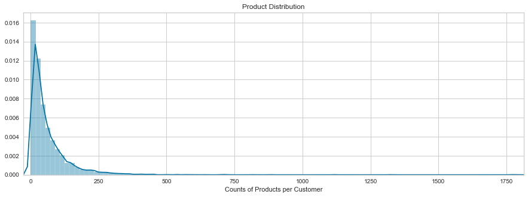

```python
plt.figure(figsize=(15,5))
sns.distplot(product_df.StockCode, bins=100)
plt.title('Product Distribution')
plt.xlabel('Counts of Products per Customer')
plt.margins(x=0)
plt.show()
```

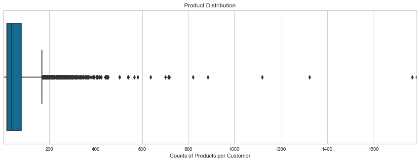

```python
plt.figure(figsize=(15,5))
sns.boxplot(product_df.StockCode)
plt.title('Product Distribution')
plt.xlabel('Counts of Products per Customer')
plt.margins(x=0)
plt.show()
```

```python
df1[df1.CustomerID == 14911].nunique()
```

```
InvoiceNo       201
StockCode      1787
Description    1816
Quantity         44
InvoiceDate     201
UnitPrice       102
CustomerID        1
Country           1
dtype: int64
```

*CustomerID 14911 had 201 Invoices and ordered 1787 unique products or items. According to box plot most of the unique number of orders per customer are around the average of 61.48. Some of the customers can have very large amount of orders, thus they have large amount of unique items in their orders. Therefore we cant say that these are outliers just lokking at the boxplot or distplot.*

### vi. Explore Customers by Country

1. What's the total revenue per country?

```python
df1["Total"] = df1["UnitPrice"] * df1["Quantity"]
df1.head()
```

|  | InvoiceNo | StockCode | Description | Quantity | InvoiceDate | UnitPrice | CustomerID | Country | Total |
| --- | --- | --- | --- | --- | --- | --- | --- | --- | --- |
| 0 | 536365 | 85123A | WHITE HANGING HEART T-LIGHT HOLDER | 6 | 2010-12-01 08:26:00 | 2.5 | 17,850.0 | United Kingdom | 15.3 |
| 1 | 536365 | 71053 | WHITE METAL LANTERN | 6 | 2010-12-01 08:26:00 | 3.4 | 17,850.0 | United Kingdom | 20.3 |
| 2 | 536365 | 84406B | CREAM CUPID HEARTS COAT HANGER | 8 | 2010-12-01 08:26:00 | 2.8 | 17,850.0 | United Kingdom | 22.0 |
| 3 | 536365 | 84029G | KNITTED UNION FLAG HOT WATER BOTTLE | 6 | 2010-12-01 08:26:00 | 3.4 | 17,850.0 | United Kingdom | 20.3 |
| 4 | 536365 | 84029E | RED WOOLLY HOTTIE WHITE HEART. | 6 | 2010-12-01 08:26:00 | 3.4 | 17,850.0 | United Kingdom | 20.3 |

```python
df1.shape
```

```
(392732, 9)
```

```python
pd.set_option('display.float_format', lambda x: '%.3f' % x)
```

```python
total_df = df1.groupby("Country").Total.sum().to_frame().sort_values(by="Total", ascending=False)
total_df
```

| Country | Total |
| --- | --- |
| United Kingdom | 7285024.644 |
| Netherlands | 285446.340 |
| EIRE | 265262.460 |
| Germany | 228678.400 |
| France | 208934.310 |
| Australia | 138453.810 |
| Spain | 61558.560 |
| Switzerland | 56443.950 |
| Belgium | 41196.340 |
| Sweden | 38367.830 |
| Japan | 37416.370 |
| Norway | 36165.440 |
| Portugal | 33375.840 |
| Finland | 22546.080 |
| Singapore | 21279.290 |
| Channel Islands | 20440.540 |
| Denmark | 18955.340 |
| Italy | 17483.240 |
| Cyprus | 13502.850 |
| Austria | 10198.680 |
| Poland | 7334.650 |
| Israel | 7215.840 |
| Greece | 4760.520 |
| Iceland | 4310.000 |
| Canada | 3666.380 |
| USA | 3580.390 |
| Malta | 2725.590 |
| Unspecified | 2660.770 |
| United Arab Emirates | 1902.280 |
| Lebanon | 1693.880 |
| Lithuania | 1661.060 |
| European Community | 1300.250 |
| Brazil | 1143.600 |
| RSA | 1002.310 |
| Czech Republic | 826.740 |
| Bahrain | 548.400 |
| Saudi Arabia | 145.920 |

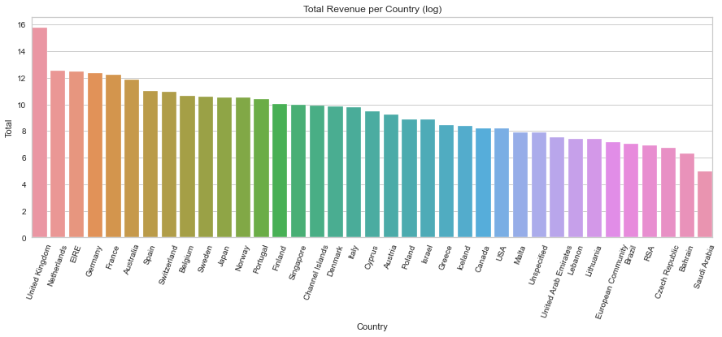

```python
plt.figure(figsize=(15,5))
sns.barplot(x=total_df.index, y=np.log(total_df.Total))
plt.title('Total Revenue per Country (log)')
plt.xlabel('Country')
plt.margins(x=0)
plt.xticks(rotation=70)
plt.show()
```

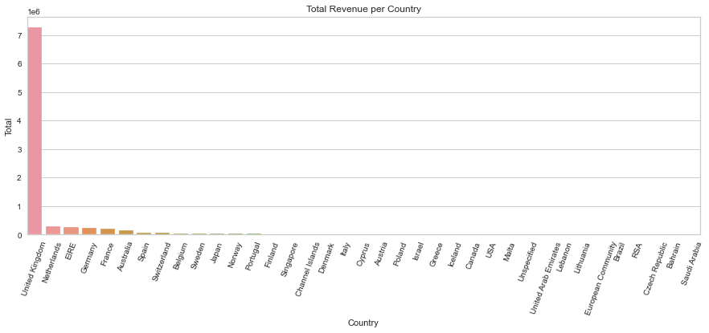

```python
plt.figure(figsize=(15,5))
sns.barplot(x=total_df.index, y=total_df.Total)
plt.title('Total Revenue per Country')
plt.xlabel('Country')
plt.margins(x=0)
plt.xticks(rotation=70)
plt.show()
```

1. Visualize number of customer per country

```python
df1.groupby("Country")["CustomerID"].nunique()
```

```
Country
Australia                  9
Austria                   11
Bahrain                    2
Belgium                   25
Brazil                     1
Canada                     4
Channel Islands            9
Cyprus                     8
Czech Republic             1
Denmark                    9
EIRE                       3
European Community         1
Finland                   12
France                    87
Germany                   94
Greece                     4
Iceland                    1
Israel                     3
Italy                     14
Japan                      8
Lebanon                    1
Lithuania                  1
Malta                      2
Netherlands                9
Norway                    10
Poland                     6
Portugal                  19
RSA                        1
Saudi Arabia               1
Singapore                  1
Spain                     30
Sweden                     8
Switzerland               21
USA                        4
United Arab Emirates       2
United Kingdom          3921
Unspecified                4
Name: CustomerID, dtype: int64
```

```python
customer_df = df1.groupby("Country").CustomerID.nunique().to_frame().sort_values(by="CustomerID", ascending=False)
customer_df
```

| Country | CustomerID |
| --- | --- |
| United Kingdom | 3921 |
| Germany | 94 |
| France | 87 |
| Spain | 30 |
| Belgium | 25 |
| Switzerland | 21 |
| Portugal | 19 |
| Italy | 14 |
| Finland | 12 |
| Austria | 11 |
| Norway | 10 |
| Netherlands | 9 |
| Australia | 9 |
| Denmark | 9 |
| Channel Islands | 9 |
| Cyprus | 8 |
| Sweden | 8 |
| Japan | 8 |
| Poland | 6 |
| USA | 4 |
| Canada | 4 |
| Unspecified | 4 |
| Greece | 4 |
| EIRE | 3 |
| Israel | 3 |
| Malta | 2 |
| United Arab Emirates | 2 |
| Bahrain | 2 |
| Czech Republic | 1 |
| Lithuania | 1 |
| Lebanon | 1 |
| RSA | 1 |
| Saudi Arabia | 1 |
| Singapore | 1 |
| Iceland | 1 |
| Brazil | 1 |
| European Community | 1 |

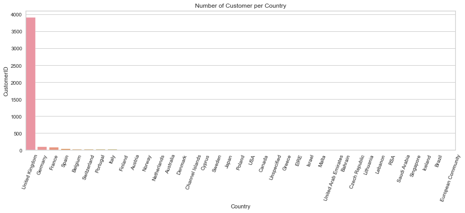

```python
plt.figure(figsize=(15,5))
sns.barplot(x=customer_df.index, y=customer_df.CustomerID)
plt.title('Number of Customer per Country')
plt.xlabel('Country')
plt.margins(x=0)
plt.xticks(rotation=70)
plt.show()
```

(??) 3. Visualize total cost per country

```python
df1.head(2)
```

|  | InvoiceNo | StockCode | Description | Quantity | InvoiceDate | UnitPrice | CustomerID | Country | Total |
| --- | --- | --- | --- | --- | --- | --- | --- | --- | --- |
| 0 | 536365 | 85123A | WHITE HANGING HEART T-LIGHT HOLDER | 6 | 2010-12-01 08:26:00 | 2.550 | 17850.000 | United Kingdom | 15.300 |
| 1 | 536365 | 71053 | WHITE METAL LANTERN | 6 | 2010-12-01 08:26:00 | 3.390 | 17850.000 | United Kingdom | 20.340 |

```python
df1.shape
```

```
(392732, 9)
```

##### The UK not only has the most sales revenue, but also the most customers. Since the majority of this data set contains orders from the UK, we can explore the UK market further by finding out what products the customers buy together and any other buying behaviors to improve our sales and targeting strategy.

```python
df1[df1.Country == "United Kingdom"]
```

|  | InvoiceNo | StockCode | Description | Quantity | InvoiceDate | UnitPrice | CustomerID | Country | Total |
| --- | --- | --- | --- | --- | --- | --- | --- | --- | --- |
| 0 | 536365 | 85123A | WHITE HANGING HEART T-LIGHT HOLDER | 6 | 2010-12-01 08:26:00 | 2.550 | 17850.000 | United Kingdom | 15.300 |
| 1 | 536365 | 71053 | WHITE METAL LANTERN | 6 | 2010-12-01 08:26:00 | 3.390 | 17850.000 | United Kingdom | 20.340 |
| 2 | 536365 | 84406B | CREAM CUPID HEARTS COAT HANGER | 8 | 2010-12-01 08:26:00 | 2.750 | 17850.000 | United Kingdom | 22.000 |
| 3 | 536365 | 84029G | KNITTED UNION FLAG HOT WATER BOTTLE | 6 | 2010-12-01 08:26:00 | 3.390 | 17850.000 | United Kingdom | 20.340 |
| 4 | 536365 | 84029E | RED WOOLLY HOTTIE WHITE HEART. | 6 | 2010-12-01 08:26:00 | 3.390 | 17850.000 | United Kingdom | 20.340 |
| ... | ... | ... | ... | ... | ... | ... | ... | ... | ... |
| 541889 | 581585 | 22466 | FAIRY TALE COTTAGE NIGHT LIGHT | 12 | 2011-12-09 12:31:00 | 1.950 | 15804.000 | United Kingdom | 23.400 |
| 541890 | 581586 | 22061 | LARGE CAKE STAND HANGING STRAWBERY | 8 | 2011-12-09 12:49:00 | 2.950 | 13113.000 | United Kingdom | 23.600 |
| 541891 | 581586 | 23275 | SET OF 3 HANGING OWLS OLLIE BEAK | 24 | 2011-12-09 12:49:00 | 1.250 | 13113.000 | United Kingdom | 30.000 |
| 541892 | 581586 | 21217 | RED RETROSPOT ROUND CAKE TINS | 24 | 2011-12-09 12:49:00 | 8.950 | 13113.000 | United Kingdom | 214.800 |
| 541893 | 581586 | 20685 | DOORMAT RED RETROSPOT | 10 | 2011-12-09 12:49:00 | 7.080 | 13113.000 | United Kingdom | 70.800 |

349227 rows × 9 columns

### vii. Explore the UK Market

1. Create df_uk DataFrame

```python
df_uk = df1[df1.Country == "United Kingdom"]
```

*Dataset decreased from 392732 to 349227*

```python
df_uk[df_uk.duplicated(keep=False)]
```

|  | InvoiceNo | StockCode | Description | Quantity | InvoiceDate | UnitPrice | CustomerID | Country | Total |
| --- | --- | --- | --- | --- | --- | --- | --- | --- | --- |

```python
df_uk[(df_uk.InvoiceNo == 536409) & (df_uk.StockCode==22111)]
```

|  | InvoiceNo | StockCode | Description | Quantity | InvoiceDate | UnitPrice | CustomerID | Country | Total |
| --- | --- | --- | --- | --- | --- | --- | --- | --- | --- |
| 485 | 536409 | 22111 | SCOTTIE DOG HOT WATER BOTTLE | 1 | 2010-12-01 11:45:00 | 4.950 | 17908.000 | United Kingdom | 4.950 |

```python
# duplicate rows are cleaned
df_uk = df_uk.drop_duplicates()
```

```python
df_uk[df_uk.duplicated()]
```

|  | InvoiceNo | StockCode | Description | Quantity | InvoiceDate | UnitPrice | CustomerID | Country | Total |
| --- | --- | --- | --- | --- | --- | --- | --- | --- | --- |

```python
df_uk.shape
```

```
(349227, 9)
```

1. What are the most popular products that are bought in the UK?

```python
df_uk.groupby(['StockCode', 'Description'], as_index=False).Quantity.sum().sort_values("Quantity",ascending=False)
```

|  | StockCode | Description | Quantity |
| --- | --- | --- | --- |
| 2514 | 23843 | PAPER CRAFT , LITTLE BIRDIE | 80995 |
| 2016 | 23166 | MEDIUM CERAMIC TOP STORAGE JAR | 76919 |
| 2690 | 84077 | WORLD WAR 2 GLIDERS ASSTD DESIGNS | 49086 |
| 3548 | 85099B | JUMBO BAG RED RETROSPOT | 41878 |
| 3555 | 85123A | WHITE HANGING HEART T-LIGHT HOLDER | 34630 |
| ... | ... | ... | ... |
| 3730 | 90125E | AMBER BERTIE GLASS BEAD BAG CHARM | 1 |
| 3162 | 47503J | SET/3 FLORAL GARDEN TOOLS IN BAG | 1 |
| 63 | 20667 | CHERRY BLOSSOM PURSE | 1 |
| 3717 | 90122B | JADE CRYSTAL+GLASS BRACELET | 1 |
| 2519 | 35645 | VINTAGE BEAD PINK JEWEL BOX | 1 |

3864 rows × 3 columns

*In the list above, there are some duplicated rows because of different inputs of description for same stockcode. Lets tackle with it*

```python
df_uk['Quantity_Sum'] = df_uk.groupby('StockCode').Quantity.transform('sum')
df_uk.head()
```

|  | InvoiceNo | StockCode | Description | Quantity | InvoiceDate | UnitPrice | CustomerID | Country | Total | Quantity_Sum |
| --- | --- | --- | --- | --- | --- | --- | --- | --- | --- | --- |
| 0 | 536365 | 85123A | WHITE HANGING HEART T-LIGHT HOLDER | 6 | 2010-12-01 08:26:00 | 2.550 | 17850.000 | United Kingdom | 15.300 | 34687 |
| 1 | 536365 | 71053 | WHITE METAL LANTERN | 6 | 2010-12-01 08:26:00 | 3.390 | 17850.000 | United Kingdom | 20.340 | 1575 |
| 2 | 536365 | 84406B | CREAM CUPID HEARTS COAT HANGER | 8 | 2010-12-01 08:26:00 | 2.750 | 17850.000 | United Kingdom | 22.000 | 1354 |
| 3 | 536365 | 84029G | KNITTED UNION FLAG HOT WATER BOTTLE | 6 | 2010-12-01 08:26:00 | 3.390 | 17850.000 | United Kingdom | 20.340 | 2384 |
| 4 | 536365 | 84029E | RED WOOLLY HOTTIE WHITE HEART. | 6 | 2010-12-01 08:26:00 | 3.390 | 17850.000 | United Kingdom | 20.340 | 3450 |

```python
df_uk[df_uk.StockCode==22197]
```

|  | InvoiceNo | StockCode | Description | Quantity | InvoiceDate | UnitPrice | CustomerID | Country | Total | Quantity_Sum |
| --- | --- | --- | --- | --- | --- | --- | --- | --- | --- | --- |
| 221 | 536390 | 22197 | SMALL POPCORN HOLDER | 100 | 2010-12-01 10:19:00 | 0.720 | 17511.000 | United Kingdom | 72.000 | 45609 |
| 393 | 536404 | 22197 | SMALL POPCORN HOLDER | 36 | 2010-12-01 11:29:00 | 0.850 | 16218.000 | United Kingdom | 30.600 | 45609 |
| 532 | 536409 | 22197 | SMALL POPCORN HOLDER | 2 | 2010-12-01 11:45:00 | 0.850 | 17908.000 | United Kingdom | 1.700 | 45609 |
| 610 | 536412 | 22197 | SMALL POPCORN HOLDER | 5 | 2010-12-01 11:49:00 | 0.850 | 17920.000 | United Kingdom | 4.250 | 45609 |
| 804 | 536464 | 22197 | SMALL POPCORN HOLDER | 5 | 2010-12-01 12:23:00 | 0.850 | 17968.000 | United Kingdom | 4.250 | 45609 |
| ... | ... | ... | ... | ... | ... | ... | ... | ... | ... | ... |
| 539984 | 581453 | 22197 | POPCORN HOLDER | 100 | 2011-12-08 18:15:00 | 0.720 | 16401.000 | United Kingdom | 72.000 | 45609 |
| 540070 | 581458 | 22197 | POPCORN HOLDER | 1500 | 2011-12-08 18:45:00 | 0.720 | 17949.000 | United Kingdom | 1080.000 | 45609 |
| 540071 | 581459 | 22197 | POPCORN HOLDER | 1200 | 2011-12-08 18:46:00 | 0.720 | 17949.000 | United Kingdom | 864.000 | 45609 |
| 541678 | 581538 | 22197 | POPCORN HOLDER | 4 | 2011-12-09 11:34:00 | 0.850 | 14446.000 | United Kingdom | 3.400 | 45609 |
| 541825 | 581579 | 22197 | POPCORN HOLDER | 24 | 2011-12-09 12:19:00 | 0.850 | 17581.000 | United Kingdom | 20.400 | 45609 |

965 rows × 10 columns

```python
most_popular = df_uk.sort_values(by='Quantity_Sum', ascending=False).groupby(['StockCode','Description'], sort=False)['Quantity_Sum'].unique().to_frame()
most_popular.reset_index().head(20)
```

|  | StockCode | Description | Quantity_Sum |
| --- | --- | --- | --- |
| 0 | 23843 | PAPER CRAFT , LITTLE BIRDIE | [80995] |
| 1 | 23166 | MEDIUM CERAMIC TOP STORAGE JAR | [76919] |
| 2 | 84077 | WORLD WAR 2 GLIDERS ASSTD DESIGNS | [49086] |
| 3 | 22197 | SMALL POPCORN HOLDER | [45609] |
| 4 | 22197 | POPCORN HOLDER | [45609] |
| 5 | 85099B | JUMBO BAG RED RETROSPOT | [41878] |
| 6 | 85123A | WHITE HANGING HEART T-LIGHT HOLDER | [34687] |
| 7 | 85123A | CREAM HANGING HEART T-LIGHT HOLDER | [34687] |
| 8 | 84879 | ASSORTED COLOUR BIRD ORNAMENT | [32628] |
| 9 | 22616 | PACK OF 12 LONDON TISSUES | [24321] |
| 10 | 17003 | BROCADE RING PURSE | [22675] |
| 11 | 21212 | PACK OF 72 RETROSPOT CAKE CASES | [22442] |
| 12 | 22178 | VICTORIAN GLASS HANGING T-LIGHT | [21876] |
| 13 | 21977 | PACK OF 60 PINK PAISLEY CAKE CASES | [19959] |
| 14 | 15036 | ASSORTED COLOURS SILK FAN | [19116] |
| 15 | 22386 | JUMBO BAG PINK POLKADOT | [18075] |
| 16 | 23203 | JUMBO BAG DOILEY PATTERNS | [16972] |
| 17 | 23203 | JUMBO BAG VINTAGE DOILY | [16972] |
| 18 | 23203 | JUMBO BAG VINTAGE DOILEY | [16972] |
| 19 | 21915 | RED HARMONICA IN BOX | [16895] |

```python
top_20 = most_popular.reset_index().head(25)
top_20
```

|  | StockCode | Description | Quantity_Sum |
| --- | --- | --- | --- |
| 0 | 23843 | PAPER CRAFT , LITTLE BIRDIE | [80995] |
| 1 | 23166 | MEDIUM CERAMIC TOP STORAGE JAR | [76919] |
| 2 | 84077 | WORLD WAR 2 GLIDERS ASSTD DESIGNS | [49086] |
| 3 | 22197 | SMALL POPCORN HOLDER | [45609] |
| 4 | 22197 | POPCORN HOLDER | [45609] |
| 5 | 85099B | JUMBO BAG RED RETROSPOT | [41878] |
| 6 | 85123A | WHITE HANGING HEART T-LIGHT HOLDER | [34687] |
| 7 | 85123A | CREAM HANGING HEART T-LIGHT HOLDER | [34687] |
| 8 | 84879 | ASSORTED COLOUR BIRD ORNAMENT | [32628] |
| 9 | 22616 | PACK OF 12 LONDON TISSUES | [24321] |
| 10 | 17003 | BROCADE RING PURSE | [22675] |
| 11 | 21212 | PACK OF 72 RETROSPOT CAKE CASES | [22442] |
| 12 | 22178 | VICTORIAN GLASS HANGING T-LIGHT | [21876] |
| 13 | 21977 | PACK OF 60 PINK PAISLEY CAKE CASES | [19959] |
| 14 | 15036 | ASSORTED COLOURS SILK FAN | [19116] |
| 15 | 22386 | JUMBO BAG PINK POLKADOT | [18075] |
| 16 | 23203 | JUMBO BAG DOILEY PATTERNS | [16972] |
| 17 | 23203 | JUMBO BAG VINTAGE DOILY | [16972] |
| 18 | 23203 | JUMBO BAG VINTAGE DOILEY | [16972] |
| 19 | 21915 | RED HARMONICA IN BOX | [16895] |
| 20 | 22469 | HEART OF WICKER SMALL | [16354] |
| 21 | 84946 | ANTIQUE SILVER T-LIGHT GLASS | [16220] |
| 22 | 84946 | ANTIQUE SILVER TEA GLASS ETCHED | [16220] |
| 23 | 85099F | JUMBO BAG STRAWBERRY | [15765] |
| 24 | 22086 | PAPER CHAIN KIT 50'S CHRISTMAS | [14772] |

```python
top_20['Quantity_Sum'] = top_20.Quantity_Sum.apply(lambda x: x[0])
```

```python
top_20.duplicated(['StockCode', 'Quantity_Sum'])
```

```
0     False
1     False
2     False
3     False
4      True
5     False
6     False
7      True
8     False
9     False
10    False
11    False
12    False
13    False
14    False
15    False
16    False
17     True
18     True
19    False
20    False
21    False
22     True
23    False
24    False
dtype: bool
```

```python
top_20 = top_20.drop_duplicates(['StockCode', 'Quantity_Sum'])
top_20
```

|  | StockCode | Description | Quantity_Sum |
| --- | --- | --- | --- |
| 0 | 23843 | PAPER CRAFT , LITTLE BIRDIE | 80995 |
| 1 | 23166 | MEDIUM CERAMIC TOP STORAGE JAR | 76919 |
| 2 | 84077 | WORLD WAR 2 GLIDERS ASSTD DESIGNS | 49086 |
| 3 | 22197 | SMALL POPCORN HOLDER | 45609 |
| 5 | 85099B | JUMBO BAG RED RETROSPOT | 41878 |
| 6 | 85123A | WHITE HANGING HEART T-LIGHT HOLDER | 34687 |
| 8 | 84879 | ASSORTED COLOUR BIRD ORNAMENT | 32628 |
| 9 | 22616 | PACK OF 12 LONDON TISSUES | 24321 |
| 10 | 17003 | BROCADE RING PURSE | 22675 |
| 11 | 21212 | PACK OF 72 RETROSPOT CAKE CASES | 22442 |
| 12 | 22178 | VICTORIAN GLASS HANGING T-LIGHT | 21876 |
| 13 | 21977 | PACK OF 60 PINK PAISLEY CAKE CASES | 19959 |
| 14 | 15036 | ASSORTED COLOURS SILK FAN | 19116 |
| 15 | 22386 | JUMBO BAG PINK POLKADOT | 18075 |
| 16 | 23203 | JUMBO BAG DOILEY PATTERNS | 16972 |
| 19 | 21915 | RED HARMONICA IN BOX | 16895 |
| 20 | 22469 | HEART OF WICKER SMALL | 16354 |
| 21 | 84946 | ANTIQUE SILVER T-LIGHT GLASS | 16220 |
| 23 | 85099F | JUMBO BAG STRAWBERRY | 15765 |
| 24 | 22086 | PAPER CHAIN KIT 50'S CHRISTMAS | 14772 |

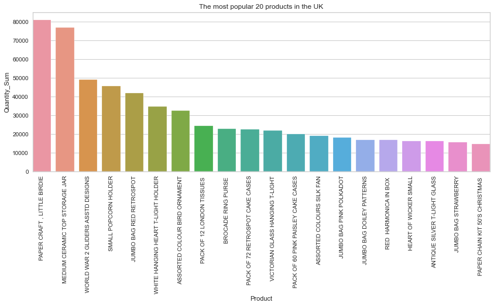

```python
plt.figure(figsize=(14,5))
sns.barplot(x='Description', y='Quantity_Sum', data=top_20)
plt.title('The most popular 20 products in the UK')
plt.xlabel('Product')
plt.margins(x=0)
plt.xticks(rotation=90)
plt.grid(True, axis="y")
plt.show()
```

### We will continue analyzing the UK transactions with customer segmentation.

# 2. RFM Analysis

In the age of the internet and e-commerce, companies that do not expand their businesses online or utilize digital tools to reach their customers will run into issues like scalability and a lack of digital precsence. An important marketing strategy e-commerce businesses use for analyzing and predicting customer value is customer segmentation. Customer data is used to sort customers into group based on their behaviors and preferences.

**[RFM](https://www.putler.com/rfm-analysis/) (Recency, Frequency, Monetary) Analysis** is a customer segmentation technique for analyzing customer value based on past buying behavior. RFM analysis was first used by the direct mail industry more than four decades ago, yet it is still an effective way to optimize your marketing.  
Our goal in this Notebook is to cluster the customers in our data set to:

- Recognize who are our most valuable customers
- Increase revenue
- Increase customer retention
- Learn more about the trends and behaviors of our customers
- Define customers that are at risk

We will start with **RFM Analysis** and then compliment our findings with predictive analysis using **K-Means Clustering Algorithms.**

- RECENCY (R): Time since last purchase
- FREQUENCY (F): Total number of purchases
- MONETARY VALUE (M): Total monetary value

Benefits of RFM Analysis

- Increased customer retention
- Increased response rate
- Increased conversion rate
- Increased revenue

RFM Analysis answers the following questions:

- Who are our best customers?
- Who has the potential to be converted into more profitable customers?
- Which customers do we need to retain?
- Which group of customers is most likely to respond to our marketing campaign?

### ii. Review df_uk DataFrame

```python
df_uk.shape
```

```
(349227, 10)
```

```python
df_uk.info()
```

```
<class 'pandas.core.frame.DataFrame'>
Int64Index: 349227 entries, 0 to 541893
Data columns (total 10 columns):
 #   Column        Non-Null Count   Dtype
---  ------        --------------   -----
 0   InvoiceNo     349227 non-null  object
 1   StockCode     349227 non-null  object
 2   Description   349227 non-null  object
 3   Quantity      349227 non-null  int64
 4   InvoiceDate   349227 non-null  datetime64[ns]
 5   UnitPrice     349227 non-null  float64
 6   CustomerID    349227 non-null  float64
 7   Country       349227 non-null  object
 8   Total         349227 non-null  float64
 9   Quantity_Sum  349227 non-null  int64
dtypes: datetime64[ns](1), float64(3), int64(2), object(4)
memory usage: 29.3+ MB
```

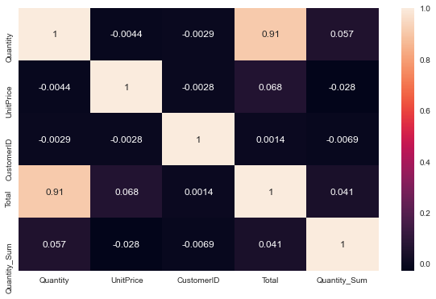

```python
plt.figure(figsize=(10,6))
sns.heatmap(df_uk.corr(),annot=True)
plt.show()
```

### iii. Recency: Days since last purchase

To calculate the recency values, follow these steps in order:

1. To calculate recency, we need to choose a date as a point of reference to evaluate how many days ago was the customer's last purchase.
2. Create a new column called Date which contains the invoice date without the timestamp
3. Group by CustomerID and check the last date of purchase
4. Calculate the days since last purchase
5. Drop Last_Purchase_Date since we don't need it anymore
6. Plot RFM distributions
1. Choose a date as a point of reference to evaluate how many days ago was the customer's last purchase.

```python
df_uk.head(2)
```

|  | InvoiceNo | StockCode | Description | Quantity | InvoiceDate | UnitPrice | CustomerID | Country | Total | Quantity_Sum |
| --- | --- | --- | --- | --- | --- | --- | --- | --- | --- | --- |
| 0 | 536365 | 85123A | WHITE HANGING HEART T-LIGHT HOLDER | 6 | 2010-12-01 08:26:00 | 2.550 | 17850.000 | United Kingdom | 15.300 | 34687 |
| 1 | 536365 | 71053 | WHITE METAL LANTERN | 6 | 2010-12-01 08:26:00 | 3.390 | 17850.000 | United Kingdom | 20.340 | 1575 |

```python
df_uk.InvoiceDate.max()
```

```
Timestamp('2011-12-09 12:49:00')
```

```python
df_uk.InvoiceDate.min()
```

```
Timestamp('2010-12-01 08:26:00')
```

*The last date in DataSet is 2011-12-09 and 2 days after this date can be taken as a reference date*

1. Create a new column called Date which contains the invoice date without the timestamp

```python
df_uk["Date"] = df_uk.InvoiceDate.dt.date
df_uk.head()
```

|  | InvoiceNo | StockCode | Description | Quantity | InvoiceDate | UnitPrice | CustomerID | Country | Total | Quantity_Sum | Date |
| --- | --- | --- | --- | --- | --- | --- | --- | --- | --- | --- | --- |
| 0 | 536365 | 85123A | WHITE HANGING HEART T-LIGHT HOLDER | 6 | 2010-12-01 08:26:00 | 2.550 | 17850.000 | United Kingdom | 15.300 | 34687 | 2010-12-01 |
| 1 | 536365 | 71053 | WHITE METAL LANTERN | 6 | 2010-12-01 08:26:00 | 3.390 | 17850.000 | United Kingdom | 20.340 | 1575 | 2010-12-01 |
| 2 | 536365 | 84406B | CREAM CUPID HEARTS COAT HANGER | 8 | 2010-12-01 08:26:00 | 2.750 | 17850.000 | United Kingdom | 22.000 | 1354 | 2010-12-01 |
| 3 | 536365 | 84029G | KNITTED UNION FLAG HOT WATER BOTTLE | 6 | 2010-12-01 08:26:00 | 3.390 | 17850.000 | United Kingdom | 20.340 | 2384 | 2010-12-01 |
| 4 | 536365 | 84029E | RED WOOLLY HOTTIE WHITE HEART. | 6 | 2010-12-01 08:26:00 | 3.390 | 17850.000 | United Kingdom | 20.340 | 3450 | 2010-12-01 |

```python
df_uk.CustomerID = df_uk.CustomerID.astype("int64")
df_uk.info()
```

```
<class 'pandas.core.frame.DataFrame'>
Int64Index: 349227 entries, 0 to 541893
Data columns (total 11 columns):
 #   Column        Non-Null Count   Dtype
---  ------        --------------   -----
 0   InvoiceNo     349227 non-null  object
 1   StockCode     349227 non-null  object
 2   Description   349227 non-null  object
 3   Quantity      349227 non-null  int64
 4   InvoiceDate   349227 non-null  datetime64[ns]
 5   UnitPrice     349227 non-null  float64
 6   CustomerID    349227 non-null  int64
 7   Country       349227 non-null  object
 8   Total         349227 non-null  float64
 9   Quantity_Sum  349227 non-null  int64
 10  Date          349227 non-null  object
dtypes: datetime64[ns](1), float64(2), int64(3), object(5)
memory usage: 32.0+ MB
```

1. Group by CustomerID and check the last date of purchase

```python
df_last = df_uk.groupby(by="CustomerID")["Date"].max().to_frame(name="Last_Purchase_Date")
```

```python
df_last.head()
```

| CustomerID | Last_Purchase_Date |
| --- | --- |
| 12346 | 2011-01-18 |
| 12747 | 2011-12-07 |
| 12748 | 2011-12-09 |
| 12749 | 2011-12-06 |
| 12820 | 2011-12-06 |

```python
df_uk = df_uk.merge(df_last, how="left", on="CustomerID")
```

```python
df_uk.head(20)
```

|  | InvoiceNo | StockCode | Description | Quantity | InvoiceDate | UnitPrice | CustomerID | Country | Total | Quantity_Sum | Date | Last_Purchase_Date |
| --- | --- | --- | --- | --- | --- | --- | --- | --- | --- | --- | --- | --- |
| 0 | 536365 | 85123A | WHITE HANGING HEART T-LIGHT HOLDER | 6 | 2010-12-01 08:26:00 | 2.550 | 17850 | United Kingdom | 15.300 | 34687 | 2010-12-01 | 2010-12-02 |
| 1 | 536365 | 71053 | WHITE METAL LANTERN | 6 | 2010-12-01 08:26:00 | 3.390 | 17850 | United Kingdom | 20.340 | 1575 | 2010-12-01 | 2010-12-02 |
| 2 | 536365 | 84406B | CREAM CUPID HEARTS COAT HANGER | 8 | 2010-12-01 08:26:00 | 2.750 | 17850 | United Kingdom | 22.000 | 1354 | 2010-12-01 | 2010-12-02 |
| 3 | 536365 | 84029G | KNITTED UNION FLAG HOT WATER BOTTLE | 6 | 2010-12-01 08:26:00 | 3.390 | 17850 | United Kingdom | 20.340 | 2384 | 2010-12-01 | 2010-12-02 |
| 4 | 536365 | 84029E | RED WOOLLY HOTTIE WHITE HEART. | 6 | 2010-12-01 08:26:00 | 3.390 | 17850 | United Kingdom | 20.340 | 3450 | 2010-12-01 | 2010-12-02 |
| 5 | 536365 | 22752 | SET 7 BABUSHKA NESTING BOXES | 2 | 2010-12-01 08:26:00 | 7.650 | 17850 | United Kingdom | 15.300 | 1383 | 2010-12-01 | 2010-12-02 |
| 6 | 536365 | 21730 | GLASS STAR FROSTED T-LIGHT HOLDER | 6 | 2010-12-01 08:26:00 | 4.250 | 17850 | United Kingdom | 25.500 | 473 | 2010-12-01 | 2010-12-02 |
| 7 | 536366 | 22633 | HAND WARMER UNION JACK | 6 | 2010-12-01 08:28:00 | 1.850 | 17850 | United Kingdom | 11.100 | 4694 | 2010-12-01 | 2010-12-02 |
| 8 | 536366 | 22632 | HAND WARMER RED POLKA DOT | 6 | 2010-12-01 08:28:00 | 1.850 | 17850 | United Kingdom | 11.100 | 3872 | 2010-12-01 | 2010-12-02 |
| 9 | 536367 | 84879 | ASSORTED COLOUR BIRD ORNAMENT | 32 | 2010-12-01 08:34:00 | 1.690 | 13047 | United Kingdom | 54.080 | 32628 | 2010-12-01 | 2011-11-08 |
| 10 | 536367 | 22745 | POPPY'S PLAYHOUSE BEDROOM | 6 | 2010-12-01 08:34:00 | 2.100 | 13047 | United Kingdom | 12.600 | 1218 | 2010-12-01 | 2011-11-08 |
| 11 | 536367 | 22748 | POPPY'S PLAYHOUSE KITCHEN | 6 | 2010-12-01 08:34:00 | 2.100 | 13047 | United Kingdom | 12.600 | 1367 | 2010-12-01 | 2011-11-08 |
| 12 | 536367 | 22749 | FELTCRAFT PRINCESS CHARLOTTE DOLL | 8 | 2010-12-01 08:34:00 | 3.750 | 13047 | United Kingdom | 30.000 | 1683 | 2010-12-01 | 2011-11-08 |
| 13 | 536367 | 22310 | IVORY KNITTED MUG COSY | 6 | 2010-12-01 08:34:00 | 1.650 | 13047 | United Kingdom | 9.900 | 417 | 2010-12-01 | 2011-11-08 |
| 14 | 536367 | 84969 | BOX OF 6 ASSORTED COLOUR TEASPOONS | 6 | 2010-12-01 08:34:00 | 4.250 | 13047 | United Kingdom | 25.500 | 231 | 2010-12-01 | 2011-11-08 |
| 15 | 536367 | 22623 | BOX OF VINTAGE JIGSAW BLOCKS | 3 | 2010-12-01 08:34:00 | 4.950 | 13047 | United Kingdom | 14.850 | 654 | 2010-12-01 | 2011-11-08 |
| 16 | 536367 | 22622 | BOX OF VINTAGE ALPHABET BLOCKS | 2 | 2010-12-01 08:34:00 | 9.950 | 13047 | United Kingdom | 19.900 | 1177 | 2010-12-01 | 2011-11-08 |
| 17 | 536367 | 21754 | HOME BUILDING BLOCK WORD | 3 | 2010-12-01 08:34:00 | 5.950 | 13047 | United Kingdom | 17.850 | 2483 | 2010-12-01 | 2011-11-08 |
| 18 | 536367 | 21755 | LOVE BUILDING BLOCK WORD | 3 | 2010-12-01 08:34:00 | 5.950 | 13047 | United Kingdom | 17.850 | 1815 | 2010-12-01 | 2011-11-08 |
| 19 | 536367 | 21777 | RECIPE BOX WITH METAL HEART | 4 | 2010-12-01 08:34:00 | 7.950 | 13047 | United Kingdom | 31.800 | 7 | 2010-12-01 | 2011-11-08 |

1. Calculate the days since last purchase

```python
ref_date = (df_uk.InvoiceDate.max() + pd.DateOffset(days=2)).date()
ref_date
```

```
datetime.date(2011, 12, 11)
```

```python
df_uk['Recency'] = ref_date-df_uk["Last_Purchase_Date"]
df_uk
```

|  | InvoiceNo | StockCode | Description | Quantity | InvoiceDate | UnitPrice | CustomerID | Country | Total | Quantity_Sum | Date | Last_Purchase_Date | Recency |
| --- | --- | --- | --- | --- | --- | --- | --- | --- | --- | --- | --- | --- | --- |
| 0 | 536365 | 85123A | WHITE HANGING HEART T-LIGHT HOLDER | 6 | 2010-12-01 08:26:00 | 2.550 | 17850 | United Kingdom | 15.300 | 34687 | 2010-12-01 | 2010-12-02 | 374 days |
| 1 | 536365 | 71053 | WHITE METAL LANTERN | 6 | 2010-12-01 08:26:00 | 3.390 | 17850 | United Kingdom | 20.340 | 1575 | 2010-12-01 | 2010-12-02 | 374 days |
| 2 | 536365 | 84406B | CREAM CUPID HEARTS COAT HANGER | 8 | 2010-12-01 08:26:00 | 2.750 | 17850 | United Kingdom | 22.000 | 1354 | 2010-12-01 | 2010-12-02 | 374 days |
| 3 | 536365 | 84029G | KNITTED UNION FLAG HOT WATER BOTTLE | 6 | 2010-12-01 08:26:00 | 3.390 | 17850 | United Kingdom | 20.340 | 2384 | 2010-12-01 | 2010-12-02 | 374 days |
| 4 | 536365 | 84029E | RED WOOLLY HOTTIE WHITE HEART. | 6 | 2010-12-01 08:26:00 | 3.390 | 17850 | United Kingdom | 20.340 | 3450 | 2010-12-01 | 2010-12-02 | 374 days |
| ... | ... | ... | ... | ... | ... | ... | ... | ... | ... | ... | ... | ... | ... |
| 349222 | 581585 | 22466 | FAIRY TALE COTTAGE NIGHT LIGHT | 12 | 2011-12-09 12:31:00 | 1.950 | 15804 | United Kingdom | 23.400 | 1894 | 2011-12-09 | 2011-12-09 | 2 days |
| 349223 | 581586 | 22061 | LARGE CAKE STAND HANGING STRAWBERY | 8 | 2011-12-09 12:49:00 | 2.950 | 13113 | United Kingdom | 23.600 | 513 | 2011-12-09 | 2011-12-09 | 2 days |
| 349224 | 581586 | 23275 | SET OF 3 HANGING OWLS OLLIE BEAK | 24 | 2011-12-09 12:49:00 | 1.250 | 13113 | United Kingdom | 30.000 | 2989 | 2011-12-09 | 2011-12-09 | 2 days |
| 349225 | 581586 | 21217 | RED RETROSPOT ROUND CAKE TINS | 24 | 2011-12-09 12:49:00 | 8.950 | 13113 | United Kingdom | 214.800 | 570 | 2011-12-09 | 2011-12-09 | 2 days |
| 349226 | 581586 | 20685 | DOORMAT RED RETROSPOT | 10 | 2011-12-09 12:49:00 | 7.080 | 13113 | United Kingdom | 70.800 | 3321 | 2011-12-09 | 2011-12-09 | 2 days |

349227 rows × 13 columns

```python
# timedelta is converted to integer days
df_uk.Recency = (df_uk.Recency / np.timedelta64(1,'D')).astype(int)
df_uk.head(3)
```

|  | InvoiceNo | StockCode | Description | Quantity | InvoiceDate | UnitPrice | CustomerID | Country | Total | Quantity_Sum | Date | Last_Purchase_Date | Recency |
| --- | --- | --- | --- | --- | --- | --- | --- | --- | --- | --- | --- | --- | --- |
| 0 | 536365 | 85123A | WHITE HANGING HEART T-LIGHT HOLDER | 6 | 2010-12-01 08:26:00 | 2.550 | 17850 | United Kingdom | 15.300 | 34687 | 2010-12-01 | 2010-12-02 | 374 |
| 1 | 536365 | 71053 | WHITE METAL LANTERN | 6 | 2010-12-01 08:26:00 | 3.390 | 17850 | United Kingdom | 20.340 | 1575 | 2010-12-01 | 2010-12-02 | 374 |
| 2 | 536365 | 84406B | CREAM CUPID HEARTS COAT HANGER | 8 | 2010-12-01 08:26:00 | 2.750 | 17850 | United Kingdom | 22.000 | 1354 | 2010-12-01 | 2010-12-02 | 374 |

```python
df_uk.info()
```

```
<class 'pandas.core.frame.DataFrame'>
Int64Index: 349227 entries, 0 to 349226
Data columns (total 13 columns):
 #   Column              Non-Null Count   Dtype
---  ------              --------------   -----
 0   InvoiceNo           349227 non-null  object
 1   StockCode           349227 non-null  object
 2   Description         349227 non-null  object
 3   Quantity            349227 non-null  int64
 4   InvoiceDate         349227 non-null  datetime64[ns]
 5   UnitPrice           349227 non-null  float64
 6   CustomerID          349227 non-null  int64
 7   Country             349227 non-null  object
 8   Total               349227 non-null  float64
 9   Quantity_Sum        349227 non-null  int64
 10  Date                349227 non-null  object
 11  Last_Purchase_Date  349227 non-null  object
 12  Recency             349227 non-null  int32
dtypes: datetime64[ns](1), float64(2), int32(1), int64(3), object(6)
memory usage: 36.0+ MB
```

1. Drop Last_Purchase_Date since we don't need it anymore

```python
df_uk.drop("Last_Purchase_Date", axis=1, inplace=True)
```

```python
df_uk.columns
```

```
Index(['InvoiceNo', 'StockCode', 'Description', 'Quantity', 'InvoiceDate',
       'UnitPrice', 'CustomerID', 'Country', 'Total', 'Quantity_Sum', 'Date',
       'Recency'],
      dtype='object')
```

1. Plot RFM distributions

```python
df_uk.CustomerID.nunique()
```

```
3921
```

```python
# Let’s look at customer distribution based on recency.
bool_series = df_uk[["CustomerID", "Recency"]].duplicated()
```

```python
df_recency = df_uk[bool_series == False][["CustomerID", "Recency"]].sort_values("Recency").reset_index(drop=True)
df_recency
```

|  | CustomerID | Recency |
| --- | --- | --- |
| 0 | 13426 | 2 |
| 1 | 16558 | 2 |
| 2 | 12748 | 2 |
| 3 | 16705 | 2 |
| 4 | 14051 | 2 |
| ... | ... | ... |
| 3916 | 18011 | 375 |
| 3917 | 16048 | 375 |
| 3918 | 16274 | 375 |
| 3919 | 14142 | 375 |
| 3920 | 15165 | 375 |

3921 rows × 2 columns

```python
sns.set(style="white", palette="muted", color_codes=True)
```

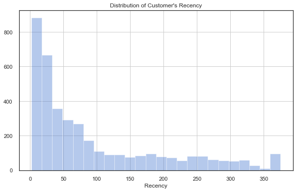

```python
plt.figure(figsize=(10,6))
sns.distplot(df_recency.Recency, kde=False)
plt.title("Distribution of Customer's Recency")
plt.grid(True)
plt.show()
```

*Here, we can note that the histogram is biased towards the left side and hence this is a sign of distribution which is a right-skewed distribution. Based on that we have a high concentration of customers in the last 100 days, i.e. the last 3 months.*

### iv. Frequency: Number of purchases

To calculate how many times a customer purchased something, we need to count how many invoices each customer has. To calculate the frequency values, follow these steps in order:

1. Make a copy of df_uk and drop duplicates

```python
df_uk2 = df_uk.copy()
```

```python
df_uk2.shape
```

```
(349227, 12)
```

```python
df_uk2.duplicated().nunique()  # there is no duplications
```

```
1
```

1. Calculate the frequency of purchases

```python
frequency_df = df_uk2.groupby(by="CustomerID").InvoiceNo.nunique().to_frame()
frequency_df.sort_values(by="InvoiceNo", ascending=False, inplace=True)
frequency_df
```

| CustomerID | InvoiceNo |
| --- | --- |
| 12748 | 210 |
| 17841 | 124 |
| 13089 | 97 |
| 14606 | 93 |
| 15311 | 91 |
| ... | ... |
| 16423 | 1 |
| 14165 | 1 |
| 14171 | 1 |
| 16415 | 1 |
| 12346 | 1 |

3921 rows × 1 columns

1. Plot RFM distributions

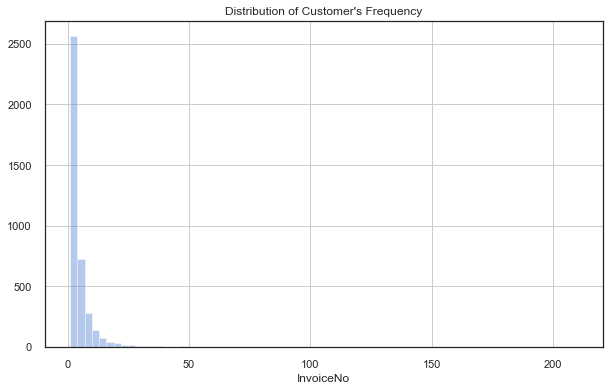

```python
plt.figure(figsize=(10,6))
sns.distplot(frequency_df.InvoiceNo, kde=False, bins=70)
plt.title("Distribution of Customer's Frequency")
plt.grid(True)
plt.show()
```

*In our database, we can see that the majority of customers do not buy more than aproximately 5 times.*

### v. Monetary: Total amount of money spent

The monetary value is calculated by adding together the cost of the customers' purchases.

1. Calculate sum total cost by customers and named "Monetary"

```python
df_uk2.head()
```

|  | InvoiceNo | StockCode | Description | Quantity | InvoiceDate | UnitPrice | CustomerID | Country | Total | Quantity_Sum | Date | Recency |
| --- | --- | --- | --- | --- | --- | --- | --- | --- | --- | --- | --- | --- |
| 0 | 536365 | 85123A | WHITE HANGING HEART T-LIGHT HOLDER | 6 | 2010-12-01 08:26:00 | 2.550 | 17850 | United Kingdom | 15.300 | 34687 | 2010-12-01 | 374 |
| 1 | 536365 | 71053 | WHITE METAL LANTERN | 6 | 2010-12-01 08:26:00 | 3.390 | 17850 | United Kingdom | 20.340 | 1575 | 2010-12-01 | 374 |
| 2 | 536365 | 84406B | CREAM CUPID HEARTS COAT HANGER | 8 | 2010-12-01 08:26:00 | 2.750 | 17850 | United Kingdom | 22.000 | 1354 | 2010-12-01 | 374 |
| 3 | 536365 | 84029G | KNITTED UNION FLAG HOT WATER BOTTLE | 6 | 2010-12-01 08:26:00 | 3.390 | 17850 | United Kingdom | 20.340 | 2384 | 2010-12-01 | 374 |
| 4 | 536365 | 84029E | RED WOOLLY HOTTIE WHITE HEART. | 6 | 2010-12-01 08:26:00 | 3.390 | 17850 | United Kingdom | 20.340 | 3450 | 2010-12-01 | 374 |

```python
df_monetary = df_uk2.groupby(by="CustomerID", as_index=False).Total.sum()  # as_index=False makes it DateFrame.
df_monetary.columns = ["CustomerID", "Monetary"]
df_monetary.sort_values(by="Monetary", ascending=False, inplace=True)
df_monetary.head()
```

|  | CustomerID | Monetary |
| --- | --- | --- |
| 3784 | 18102 | 259657.300 |
| 3315 | 17450 | 194390.790 |
| 2599 | 16446 | 168472.500 |
| 3357 | 17511 | 91062.380 |
| 2295 | 16029 | 80850.840 |

1. Plot RFM distributions

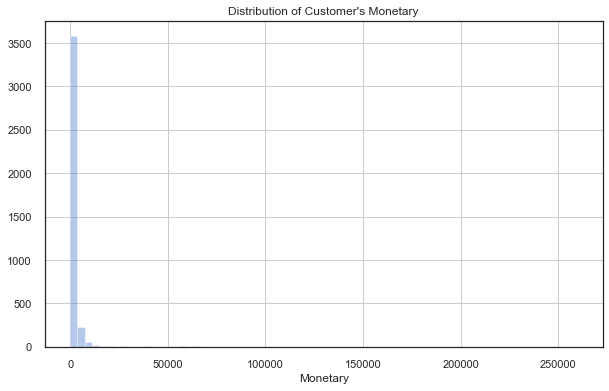

```python
plt.figure(figsize=(10,6))
sns.distplot(df_monetary.Monetary, kde=False, bins=70)
plt.title("Distribution of Customer's Monetary")
plt.grid(True)
plt.show()
```

*It is marked that many customers spend less than 5,000 pound.*

- Now let’s check the RFM table.

### vi. Create RFM Table

Merge the recency, frequency and motetary dataframes

```python
RF_df = df_recency.merge(frequency_df, on="CustomerID")
RFM_df = RF_df.merge(df_monetary, on="CustomerID")
RFM_df.columns = ["CustomerID", "Recency", "Frequency", "Monetary"]
RFM_df.set_index("CustomerID", inplace=True)
RFM_df.head()
```

| CustomerID | Recency | Frequency | Monetary |
| --- | --- | --- | --- |
| 13426 | 2 | 10 | 3641.320 |
| 16558 | 2 | 20 | 8338.490 |
| 12748 | 2 | 210 | 33053.190 |
| 16705 | 2 | 20 | 14034.990 |
| 14051 | 2 | 23 | 15610.390 |

*Thanks to our RFM table, we are now going to propose a customer segmentation strategy.*

# 3. Customer Segmentation with RFM Scores

Businesses have this ever-lasting urge to understand their customers. The better you understand the customer, the better you serve them, and the higher the financial gain you receive from that customer. Since the dawn of trade, this process of understanding customers for a strategic gain has been there practiced and this task is known majorly as [Customer Segmentation](https://clevertap.com/blog/rfm-analysis/). Well as the name suggests, Customer Segmentation could segment customers according to their precise needs. Some of the common ways of segmenting customers are based on their Recency-Frequency-Monatory values, their demographics like gender, region, country, etc, and some of their business-crafted scores. You will use Recency-Frequency-Monatory values for this case.

In this section, you will create an RFM Segmentation Table where you segment your customers by using the RFM table. For example, you can label the best customer as "Big Spenders" and the lost customer as "Lost Customer".

## Calculate RFM Scoring

The simplest way to create customer segments from an RFM model is by using **Quartiles**. We will assign a score from 1 to 4 to each category (Recency, Frequency, and Monetary) with 4 being the highest/best value. The final RFM score is calculated by combining all RFM values. For Customer Segmentation, you will use the df_rfm data set resulting from the RFM analysis.  
**Note**: Data can be assigned into more groups for better granularity, but we will use 4 in this case.

1. Divide the df_rfm into quarters

```python
RFM_df.Recency.max()
```

```
375
```

```python
RFM_df.Recency.min()
```

```
2
```

```python
RFM_df.Frequency.max()
```

```
210
```

```python
RFM_df.Frequency.min()
```

```
1
```

### i. Creating the RFM Segmentation Table

1. Create two functions, one for Recency and one for Frequency and Monetary. For Recency, customers in the first quarter should be scored as 4, this represents the highest Recency value. Conversely, for Frequency and Monetary, customers in the last quarter should be scored as 4, representing the highest Frequency and Monetary values.

```python
RFM_df.describe().T
```

|  | count | mean | std | min | 25% | 50% | 75% | max |
| --- | --- | --- | --- | --- | --- | --- | --- | --- |
| Recency | 3921.000 | 93.722 | 99.529 | 2.000 | 19.000 | 52.000 | 144.000 | 375.000 |
| Frequency | 3921.000 | 4.246 | 7.206 | 1.000 | 1.000 | 2.000 | 5.000 | 210.000 |
| Monetary | 3921.000 | 1857.951 | 7477.736 | 0.000 | 298.110 | 644.300 | 1570.810 | 259657.300 |

```python
pd.qcut(RFM_df["Recency"], q=4).head()
```

```
CustomerID
13426    (1.999, 19.0]
16558    (1.999, 19.0]
12748    (1.999, 19.0]
16705    (1.999, 19.0]
14051    (1.999, 19.0]
Name: Recency, dtype: category
Categories (4, interval[float64]): [(1.999, 19.0] < (19.0, 52.0] < (52.0, 144.0] < (144.0, 375.0]]
```

```python
# first art of function
def recency_score(x):
    if x["Recency"] <= 19:
        recency = 4
    elif x["Recency"] <= 52:
        recency = 3
    elif x["Recency"] <= 144:
        recency = 2
    else:
        recency = 1
    return recency
```

```python
# second art of function
def frequency_score(x):
    if x <= 1:
        frequency = 1
    elif x <= 2:
        frequency = 2
    elif x<= 5:
        frequency = 3
    else:
        frequency = 4
    return frequency
```

```python
pd.qcut(RFM_df["Monetary"], q=4).head()
```

```
CustomerID
13426    (1570.81, 259657.3]
16558    (1570.81, 259657.3]
12748    (1570.81, 259657.3]
16705    (1570.81, 259657.3]
14051    (1570.81, 259657.3]
Name: Monetary, dtype: category
Categories (4, interval[float64]): [(-0.001, 298.11] < (298.11, 644.3] < (644.3, 1570.81] < (1570.81, 259657.3]]
```

1. Score customers from 1 to 4 by applying the functions you have created. Also create separate score column for each value.

```python
RFM_df["R"] = RFM_df.apply(recency_score, axis=1)
RFM_df
```

| CustomerID | Recency | Frequency | Monetary | R |
| --- | --- | --- | --- | --- |
| 13426 | 2 | 10 | 3641.320 | 4 |
| 16558 | 2 | 20 | 8338.490 | 4 |
| 12748 | 2 | 210 | 33053.190 | 4 |
| 16705 | 2 | 20 | 14034.990 | 4 |
| 14051 | 2 | 23 | 15610.390 | 4 |
| ... | ... | ... | ... | ... |
| 18011 | 375 | 1 | 102.790 | 1 |
| 16048 | 375 | 2 | 256.440 | 1 |
| 16274 | 375 | 1 | 351.750 | 1 |
| 14142 | 375 | 1 | 311.810 | 1 |
| 15165 | 375 | 1 | 487.750 | 1 |

3921 rows × 4 columns

```python
RFM_df["F"] = RFM_df["Frequency"].apply(lambda x : frequency_score(x))
RFM_df
```

| CustomerID | Recency | Frequency | Monetary | R | F |
| --- | --- | --- | --- | --- | --- |
| 13426 | 2 | 10 | 3641.320 | 4 | 4 |
| 16558 | 2 | 20 | 8338.490 | 4 | 4 |
| 12748 | 2 | 210 | 33053.190 | 4 | 4 |
| 16705 | 2 | 20 | 14034.990 | 4 | 4 |
| 14051 | 2 | 23 | 15610.390 | 4 | 4 |
| ... | ... | ... | ... | ... | ... |
| 18011 | 375 | 1 | 102.790 | 1 | 1 |
| 16048 | 375 | 2 | 256.440 | 1 | 2 |
| 16274 | 375 | 1 | 351.750 | 1 | 1 |
| 14142 | 375 | 1 | 311.810 | 1 | 1 |
| 15165 | 375 | 1 | 487.750 | 1 | 1 |

3921 rows × 5 columns

```python
# These intervals will then be labelled from 1 to 4, in the same way as the recency and the frequency.
monetary_score = pd.qcut(RFM_df["Monetary"], q=4, labels=range(1, 5))
monetary_score
```

```
CustomerID
13426    4
16558    4
12748    4
16705    4
14051    4
        ..
18011    1
16048    1
16274    2
14142    2
15165    2
Name: Monetary, Length: 3921, dtype: category
Categories (4, int64): [1 < 2 < 3 < 4]
```

*So we get our final table with all the scores of Recency, Frequency, and Monetary*

```python
RFM_df = RFM_df.assign(M = monetary_score.values)
RFM_df
```

| CustomerID | Recency | Frequency | Monetary | R | F | M |
| --- | --- | --- | --- | --- | --- | --- |
| 13426 | 2 | 10 | 3641.320 | 4 | 4 | 4 |
| 16558 | 2 | 20 | 8338.490 | 4 | 4 | 4 |
| 12748 | 2 | 210 | 33053.190 | 4 | 4 | 4 |
| 16705 | 2 | 20 | 14034.990 | 4 | 4 | 4 |
| 14051 | 2 | 23 | 15610.390 | 4 | 4 | 4 |
| ... | ... | ... | ... | ... | ... | ... |
| 18011 | 375 | 1 | 102.790 | 1 | 1 | 1 |
| 16048 | 375 | 2 | 256.440 | 1 | 2 | 1 |
| 16274 | 375 | 1 | 351.750 | 1 | 1 | 2 |
| 14142 | 375 | 1 | 311.810 | 1 | 1 | 2 |
| 15165 | 375 | 1 | 487.750 | 1 | 1 | 2 |

3921 rows × 6 columns

1. Now that scored each customer, you'll combine the scores for segmentation.

*The final RFM score will be obtained by concatenating all the different R, F and M scores. This will allow us to define customer segments. As customer segmentation really depends on companies’s objectives, we will just settle for the most common segments found in the marketing field.*

```python
def rfm_score(row):
    return str(row['R']) + str(row['F']) + str(row['M'])
```

```python
RFM_df["RFM_Score"] = RFM_df.apply(rfm_score, axis=1)
RFM_df.head()
```

| CustomerID | Recency | Frequency | Monetary | R | F | M | RFM_Score |
| --- | --- | --- | --- | --- | --- | --- | --- |
| 13426 | 2 | 10 | 3641.320 | 4 | 4 | 4 | 444 |
| 16558 | 2 | 20 | 8338.490 | 4 | 4 | 4 | 444 |
| 12748 | 2 | 210 | 33053.190 | 4 | 4 | 4 | 444 |
| 16705 | 2 | 20 | 14034.990 | 4 | 4 | 4 | 444 |
| 14051 | 2 | 23 | 15610.390 | 4 | 4 | 4 | 444 |

```python
len(list(RFM_df.RFM_Score.unique()))  # 62 kombination
```

```
61
```

```python
list(RFM_df.RFM_Score.unique())
```

```
['444',
 '433',
 '434',
 '424',
 '432',
 '423',
 '443',
 '411',
 '422',
 '421',
 '412',
 '431',
 '414',
 '442',
 '441',
 '413',
 '332',
 '343',
 '334',
 '344',
 '312',
 '311',
 '333',
 '323',
 '322',
 '321',
 '313',
 '324',
 '331',
 '314',
 '223',
 '244',
 '232',
 '211',
 '212',
 '233',
 '243',
 '222',
 '224',
 '213',
 '231',
 '234',
 '221',
 '214',
 '242',
 '122',
 '111',
 '134',
 '131',
 '144',
 '133',
 '123',
 '112',
 '113',
 '132',
 '121',
 '124',
 '141',
 '114',
 '143',
 '142']
```

```python
best = ["444", "434", "443", "344", "334"]
loyal = ["441", "442", "432"]
big_spender = ["413", "414", "424", "313", "314", "114"]
almost_lost = ["214", "213", "311", "312", "411", "412", "144", "143"]
lost = ["212",  "132"]
lost_cheap = ["111", "211", "121", "112", "113"]
```

```python
label_dict = {"444":"Best", "434":"Best", "443":"Best", "344":"Best", "334": "Best",
              "441":"Loyal" , "442":"Loyal", "432":"Loyal",
             "413":"Big Spender", "414":"Big Spender", "424":"Big Spender", "313":"Big Spender", "314":"Big Spender", "114":"Big Spender",
              "423":"Big Spender", "333":"Big Spender", "324":"Big Spender",
             "214":"Almost Lost", "213":"Almost Lost", "311":"Almost Lost", "312":"Almost Lost", "411":"Almost Lost", "412":"Almost Lost",
             "144":"Almost Lost", "143": "Almost Lost",
             "212":"Lost", "132":"Lost",
             "111":"Lost Cheap", "211":"Lost Cheap", "121": "Lost Cheap", "112":"Lost Cheap", "113":"Lost Cheap",}
```

```python
"444" in label_dict.keys()
```

```
True
```

```python
def rfm_level(x):
    if x.RFM_Score in label_dict.keys():
        return label_dict[x.RFM_Score]
    else:
        return "Normal"
```

```python
RFM_df["RFM_Level"] = RFM_df.apply(rfm_level, axis=1)
RFM_df
```

| CustomerID | Recency | Frequency | Monetary | R | F | M | RFM_Score | RFM_Level |
| --- | --- | --- | --- | --- | --- | --- | --- | --- |
| 13426 | 2 | 10 | 3641.320 | 4 | 4 | 4 | 444 | Best |
| 16558 | 2 | 20 | 8338.490 | 4 | 4 | 4 | 444 | Best |
| 12748 | 2 | 210 | 33053.190 | 4 | 4 | 4 | 444 | Best |
| 16705 | 2 | 20 | 14034.990 | 4 | 4 | 4 | 444 | Best |
| 14051 | 2 | 23 | 15610.390 | 4 | 4 | 4 | 444 | Best |
| ... | ... | ... | ... | ... | ... | ... | ... | ... |
| 18011 | 375 | 1 | 102.790 | 1 | 1 | 1 | 111 | Lost Cheap |
| 16048 | 375 | 2 | 256.440 | 1 | 2 | 1 | 121 | Lost Cheap |
| 16274 | 375 | 1 | 351.750 | 1 | 1 | 2 | 112 | Lost Cheap |
| 14142 | 375 | 1 | 311.810 | 1 | 1 | 2 | 112 | Lost Cheap |
| 15165 | 375 | 1 | 487.750 | 1 | 1 | 2 | 112 | Lost Cheap |

3921 rows × 8 columns

1. Calculate average values for each RFM_Level, and return a size of each segment

```python
RFM_df["RFM_Level"].value_counts().sort_values(ascending=False)
```

```
Normal         1367
Lost Cheap      881
Best            803
Almost Lost     373
Big Spender     277
Lost            176
Loyal            44
Name: RFM_Level, dtype: int64
```

## Plot RFM Segments

1. Create your plot and resize it.

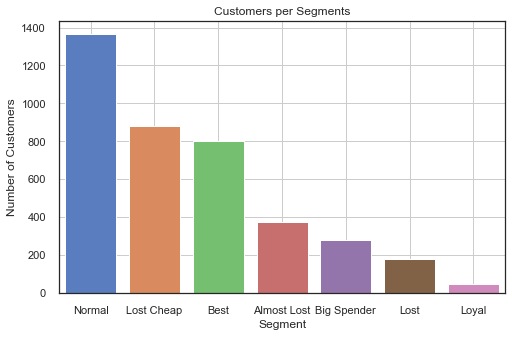

```python
# First Art
y = RFM_df["RFM_Level"].value_counts().sort_values(ascending=False).values
x = RFM_df["RFM_Level"].value_counts().sort_values(ascending=False).index
plt.figure(figsize=(8,5))
sns.barplot(x=x, y=y)
plt.title("Customers per Segments")
plt.xlabel("Segment")
plt.ylabel("Number of Customers")
plt.grid(True)
plt.show()
```

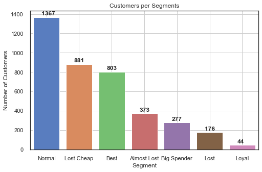

```python
# Second Art
y = RFM_df["RFM_Level"].value_counts().sort_values(ascending=False).values
x = RFM_df["RFM_Level"].value_counts().sort_values(ascending=False).index
bar, ax = plt.subplots(figsize=(8,5))
ax = sns.barplot(x=x, y=y)
ax.set_title("Customers per Segments")
ax.set_xlabel("Segment")
ax.set_ylabel("Number of Customers")
plt.grid(True)
# calculate the counts and annotate the sns barplot
for rect in ax.patches:
    ax.text(rect.get_x() - 0.15 + rect.get_width() / 2,rect.get_height() + 20,"%.f"% rect.get_height(), weight='bold' )
plt.show()
```

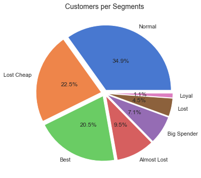

```python
# Third Art
pie, ax = plt.subplots(figsize=[8,6])
labels = x
plt.pie(x=y, autopct="%.1f%%", explode=[0.05]*7, labels=labels, pctdistance=0.5)
plt.title("Customers per Segments", fontsize=14);
```

Using customer segmentation categories found [here](http://www.blastam.com/blog/rfm-analysis-boosts-sales) we can formulate different marketing strategies and approaches for customer engagement for each type of customer.

Note: The author in the article scores 1 as the highest and 4 as the lowest

1. How many customers do we have in each segment?

```python
RFM_df["RFM_Level"].value_counts().sort_values(ascending=False)
```

```
Normal         1367
Lost Cheap      881
Best            803
Almost Lost     373
Big Spender     277
Lost            176
Loyal            44
Name: RFM_Level, dtype: int64
```

*Recomendations* :

- Best Customers and Loyals: Rewards them for their multiples purchases. They can be early adopters to very new products. Suggest them “Refer a friend”. Also, they can be the most loyal customers that have the habit to order.
- Big Spenders: Inform them about the discounts to keep them spending more and market your most expensive products
- Almost Lost: Send them aggressive price incentives and personalized emails to encourage them to order
- Lost Customers : Send them aggressive price incentives
- Lost Cheap Customers: Don’t spend too much trying to re-acquire

# 4. Applying K-Means Clustering

## Data Pre-Processing and Exploring

```python
RFM_df
```

| CustomerID | Recency | Frequency | Monetary | R | F | M | RFM_Score | RFM_Level |
| --- | --- | --- | --- | --- | --- | --- | --- | --- |
| 13426 | 2 | 10 | 3641.320 | 4 | 4 | 4 | 444 | Best |
| 16558 | 2 | 20 | 8338.490 | 4 | 4 | 4 | 444 | Best |
| 12748 | 2 | 210 | 33053.190 | 4 | 4 | 4 | 444 | Best |
| 16705 | 2 | 20 | 14034.990 | 4 | 4 | 4 | 444 | Best |
| 14051 | 2 | 23 | 15610.390 | 4 | 4 | 4 | 444 | Best |
| ... | ... | ... | ... | ... | ... | ... | ... | ... |
| 18011 | 375 | 1 | 102.790 | 1 | 1 | 1 | 111 | Lost Cheap |
| 16048 | 375 | 2 | 256.440 | 1 | 2 | 1 | 121 | Lost Cheap |
| 16274 | 375 | 1 | 351.750 | 1 | 1 | 2 | 112 | Lost Cheap |
| 14142 | 375 | 1 | 311.810 | 1 | 1 | 2 | 112 | Lost Cheap |
| 15165 | 375 | 1 | 487.750 | 1 | 1 | 2 | 112 | Lost Cheap |

3921 rows × 8 columns

```python
RFM_df.info()
```

```
<class 'pandas.core.frame.DataFrame'>
Int64Index: 3921 entries, 13426 to 15165
Data columns (total 8 columns):
 #   Column     Non-Null Count  Dtype
---  ------     --------------  -----
 0   Recency    3921 non-null   int32
 1   Frequency  3921 non-null   int64
 2   Monetary   3921 non-null   float64
 3   R          3921 non-null   int64
 4   F          3921 non-null   int64
 5   M          3921 non-null   category
 6   RFM_Score  3921 non-null   object
 7   RFM_Level  3921 non-null   object
dtypes: category(1), float64(1), int32(1), int64(3), object(2)
memory usage: 233.7+ KB
```

```python
RFM_df["M"] = RFM_df.M.astype("int64")
RFM_df.info()
```

```
<class 'pandas.core.frame.DataFrame'>
Int64Index: 3921 entries, 13426 to 15165
Data columns (total 8 columns):
 #   Column     Non-Null Count  Dtype
---  ------     --------------  -----
 0   Recency    3921 non-null   int32
 1   Frequency  3921 non-null   int64
 2   Monetary   3921 non-null   float64
 3   R          3921 non-null   int64
 4   F          3921 non-null   int64
 5   M          3921 non-null   int64
 6   RFM_Score  3921 non-null   object
 7   RFM_Level  3921 non-null   object
dtypes: float64(1), int32(1), int64(4), object(2)
memory usage: 260.4+ KB
```

### i. Define and Plot Feature Correlations

Create Heatmap and evaluate the results

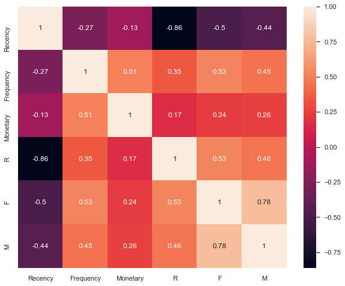

```python
plt.figure(figsize=(10,8))
sns.heatmap(RFM_df.corr(),annot=True)
plt.show()
```

*Comment: It seems that Frequency and Monetary are moderately correlated (0.51). This is also expected. Customers who often make orders have the chance to have a high Monetary Score*

### ii. Visualize Feature Distributions

To get a better understanding of the dataset, you can costruct a scatter matrix of each of the three features in the RFM data.

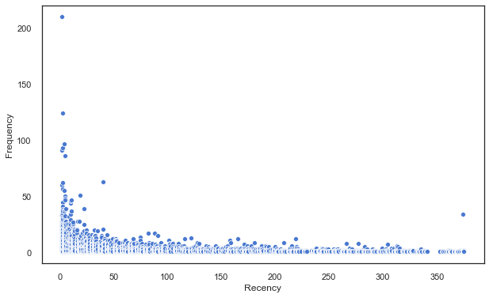

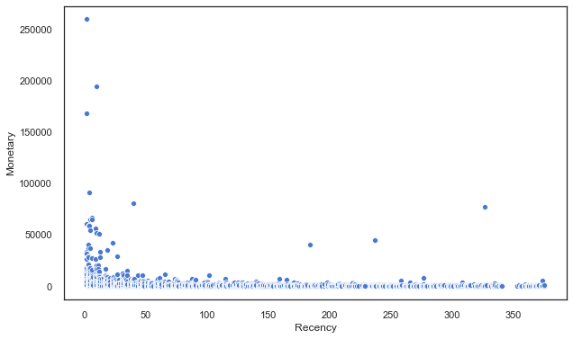

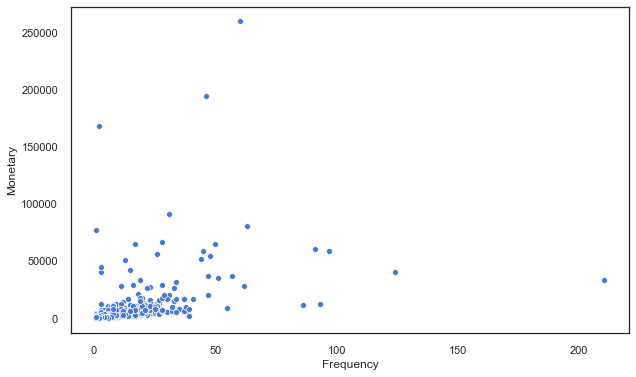

```python
plt.figure(figsize=(10, 6))
sns.scatterplot(RFM_df['Recency'], RFM_df['Frequency'])
plt.show()

plt.figure(figsize=(10, 6))
sns.scatterplot(RFM_df['Recency'], RFM_df['Monetary'])
plt.show()

plt.figure(figsize=(10, 6))
sns.scatterplot(RFM_df['Frequency'], RFM_df['Monetary'])
plt.show()
```

*Comment: Most of Our customers have frequency smaller than 100 and Monetary smaller than 100000, therefore we can focus on this customers. The customers out of this range can be dropped. But this time we ll continue as is.*

### iii. Data Normalization

1. You can use the logarithm method to normalize the values in a column.

```python
RFM_df["Log_Rec"] = np.log(RFM_df["Recency"])
```

```python
RFM_df["Log_Fre"] = np.log(RFM_df["Frequency"])
```

```python
# RFM_df["Log_Mon"] = np.log(RFM_df["Monetary"])  ## We have problem with this by getting -inf and nan values after normalization
```

```python
# RFM_df.drop("Log_Mon", inplace=True, axis=1)
```

```python
def neg_norm(x):
    """eliminates zero end negative values before log normalization, then normalize with np.log(column)"""
    if x["Monetary"] <= 0:
        log_mon = 0
    else:
        log_mon = np.log(x["Monetary"])
    return log_mon
```

```python
RFM_df["Log_Mon"] = RFM_df.apply(neg_norm, axis=1)
RFM_df.sample(10)
```

| CustomerID | Recency | Frequency | Monetary | R | F | M | RFM_Score | RFM_Level | Log_Rec | Log_Fre | Log_Mon |
| --- | --- | --- | --- | --- | --- | --- | --- | --- | --- | --- | --- |
| 16477 | 65 | 7 | 2494.460 | 2 | 4 | 4 | 244 | Normal | 4.174 | 1.946 | 7.822 |
| 16409 | 38 | 5 | 2022.980 | 3 | 3 | 4 | 334 | Best | 3.638 | 1.609 | 7.612 |
| 16553 | 165 | 12 | 5719.820 | 1 | 4 | 4 | 144 | Almost Lost | 5.106 | 2.485 | 8.652 |
| 18145 | 14 | 4 | 2861.550 | 4 | 3 | 4 | 434 | Best | 2.639 | 1.386 | 7.959 |
| 13532 | 35 | 1 | 210.310 | 3 | 1 | 1 | 311 | Almost Lost | 3.555 | 0.000 | 5.349 |
| 17600 | 19 | 1 | 161.670 | 4 | 1 | 1 | 411 | Almost Lost | 2.944 | 0.000 | 5.086 |
| 13600 | 314 | 1 | 219.520 | 1 | 1 | 1 | 111 | Lost Cheap | 5.749 | 0.000 | 5.391 |
| 16216 | 269 | 1 | 914.930 | 1 | 1 | 3 | 113 | Lost Cheap | 5.595 | 0.000 | 6.819 |
| 13309 | 9 | 5 | 1456.790 | 4 | 3 | 3 | 433 | Normal | 2.197 | 1.609 | 7.284 |
| 14720 | 7 | 3 | 663.810 | 4 | 3 | 3 | 433 | Normal | 1.946 | 1.099 | 6.498 |

```python
RFM_df.info()
```

```
<class 'pandas.core.frame.DataFrame'>
Int64Index: 3921 entries, 13426 to 15165
Data columns (total 11 columns):
 #   Column     Non-Null Count  Dtype
---  ------     --------------  -----
 0   Recency    3921 non-null   int32
 1   Frequency  3921 non-null   int64
 2   Monetary   3921 non-null   float64
 3   R          3921 non-null   int64
 4   F          3921 non-null   int64
 5   M          3921 non-null   int64
 6   RFM_Score  3921 non-null   object
 7   RFM_Level  3921 non-null   object
 8   Log_Rec    3921 non-null   float64
 9   Log_Fre    3921 non-null   float64
 10  Log_Mon    3921 non-null   float64
dtypes: float64(4), int32(1), int64(4), object(2)
memory usage: 352.3+ KB
```

```python
# pd.set_option('display.max_columns', None)
# pd.set_option('display.max_rows', None)
# pd.reset_option("display.max_rows", None)
RFM_df.loc[15350]
```

```
Recency             375
Frequency             1
Monetary        115.650
R                     1
F                     1
M                     1
RFM_Score           111
RFM_Level    Lost Cheap
Log_Rec           5.927
Log_Fre           0.000
Log_Mon           4.751
Name: 15350, dtype: object
```

1. Plot normalized data with scatter matrix or pairplot. Also evaluate results.

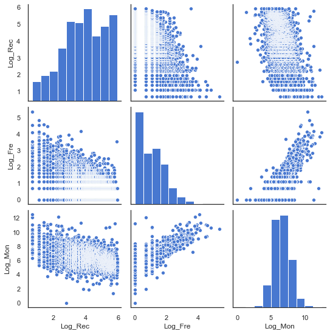

```python
plt.figure(figsize=(10, 6))
sns.pairplot(RFM_df[["Log_Rec", "Log_Fre", "Log_Mon"]])
plt.show()
```

## K-Means Implementation

```python
from sklearn.metrics import silhouette_score
```

```python
RFM_df1 = RFM_df[["Log_Rec", "Log_Fre",	"Log_Mon"]]
```

```python
from pyclustertend import hopkins
hopkins(RFM_df1,RFM_df1.shape[0])
```

```
0.06101621578306853
```

*Assess the clusterability of a dataset. A score between 0 and 1, a score around 0.5 express no clusterability and a score tending to 0 express a high cluster tendency. We have a high cluster tendency*

### i. Define the Optimal Number of Clusters

The Elbow Method

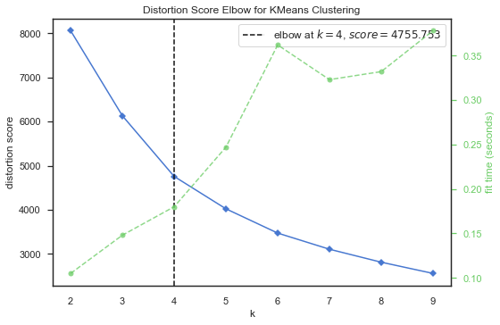

```python
from sklearn.cluster import KMeans
from yellowbrick.cluster import KElbowVisualizer

kmeans = KMeans()
visu = KElbowVisualizer(kmeans, k = (2,10))
visu.fit(RFM_df1)
visu.poof()
```

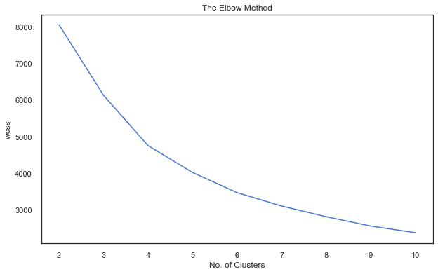

```python
wcss =[]
for n in range(2,11):
    kmeans=KMeans(n_clusters=n,random_state=0)
    kmeans.fit(RFM_df1)
    wcss.append(kmeans.inertia_)
plt.figure(figsize=(10,6))
plt.plot(range(2, 11), wcss)
plt.title('The Elbow Method')
plt.xlabel('No. of Clusters')
plt.ylabel('wcss')
plt.show()
```

[Silhouette Coefficient](http://scikit-learn.org/stable/auto_examples/cluster/plot_kmeans_silhouette_analysis.html)

```python
kmeans = KMeans(n_clusters = 2)
y_means = kmeans.fit_predict(RFM_df1)
silhouette_score(RFM_df1, y_means)
```

```
0.42108194470976956
```

```python
kmeans = KMeans(n_clusters = 3)
y_means = kmeans.fit_predict(RFM_df1)
silhouette_score(RFM_df1, y_means)
```

```
0.32590601209821385
```

```python
kmeans = KMeans(n_clusters = 4)
y_means = kmeans.fit_predict(RFM_df1)
silhouette_score(RFM_df1, y_means)
```

```
0.3449480408006643
```

```python
kmeans = KMeans(n_clusters = 5)
y_means = kmeans.fit_predict(RFM_df1)
silhouette_score(RFM_df1, y_means)
```

```
0.3264062287019767
```

```python
kmeans = KMeans(n_clusters = 6)
y_means = kmeans.fit_predict(RFM_df1)
silhouette_score(RFM_df1, y_means)
```

```
0.31494018186648054
```

```python
kmeans = KMeans(n_clusters = 7)
y_means = kmeans.fit_predict(RFM_df1)
silhouette_score(RFM_df1, y_means)
```

```
0.3147719748218762
```

*As a result we can take 4 as a cluster number.*

### ii. Model Fitting

Fit the K-Means Algorithm with the optimal number of clusters you decided and save the model to disk.

```python
kmeans_model = KMeans(n_clusters = 4).fit(RFM_df1)
```

```python
import pickle
pickle.dump(kmeans_model, open("segmentation_model", 'wb'))  # our model is saved.
```

### iii. Visualize the Clusters

1. Create a scatter plot and select cluster centers

```python
kmeans4 = KMeans(n_clusters = 4)
y_means = kmeans4.fit_predict(RFM_df1)
RFM_df1["cluster_Kmeans"] = y_means
```

```python
kmeans4.cluster_centers_
```

```
array([[4.14158748, 1.25712461, 7.15247945],
       [5.15653386, 0.19006385, 5.48517886],
       [2.97564746, 0.5404444 , 5.88317339],
       [2.19031365, 2.22300361, 8.1486937 ]])
```

```python
labels = kmeans4.labels_
```

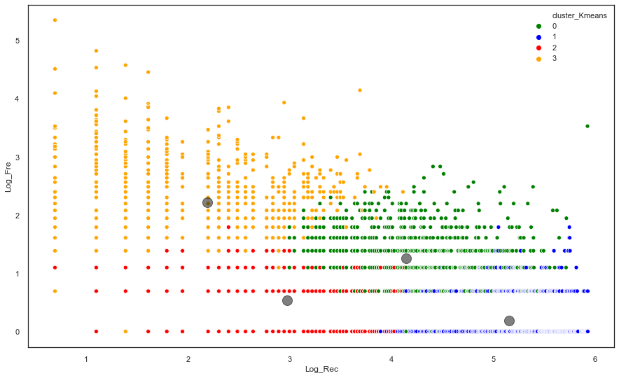

```python
# plt.figure(figsize=(15,9))
# sns.scatterplot(x='Log_Fre', y='Log_Rec', hue='cluster_Kmeans', data=RFM_df1, palette=['green','blue','red'], legend='full')

plt.figure(figsize=(15,9))
sns.scatterplot(x='Log_Rec', y="Log_Fre", hue='cluster_Kmeans', data=RFM_df1, palette=['green','blue','red', "orange"], legend='full')

# plt.scatter(x='Log_Fre', y='Log_Rec', c = labels, s = 10, cmap = "viridis", data=RFM_df1)
plt.scatter(kmeans4.cluster_centers_[:, 0], kmeans4.cluster_centers_[:, 1], s=200, c='black',alpha=0.5, label = 'Centroids')
```

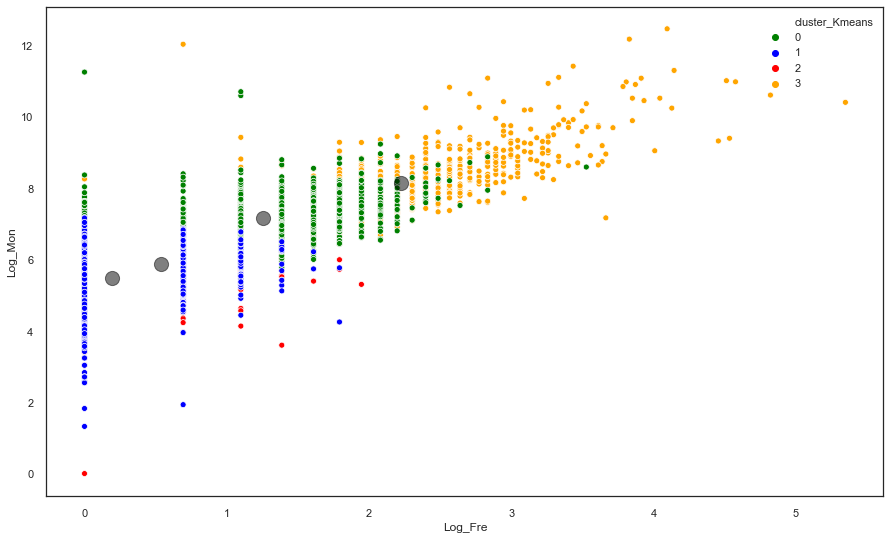

```python
# plt.figure(figsize=(15,9))
# sns.scatterplot(x='Log_Fre', y='Log_Mon', hue='cluster_Kmeans', data=RFM_df1, palette=['green','blue','red'], legend='full')

plt.figure(figsize=(15,9))
sns.scatterplot(x='Log_Fre', y='Log_Mon', hue='cluster_Kmeans', data=RFM_df1, palette=['green','blue','red', "orange"], legend='full')
plt.scatter(kmeans4.cluster_centers_[:, 1], kmeans4.cluster_centers_[:, 2], s=200, c='black',alpha=0.5, label = 'Centroids')
```

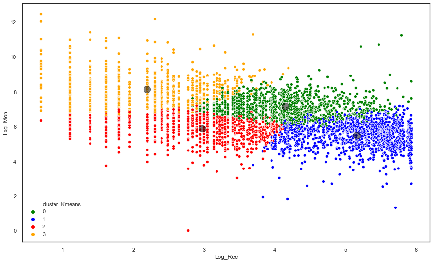

```python
# plt.figure(figsize=(15,9))
# sns.scatterplot(x='Log_Rec', y='Log_Mon', hue='cluster_Kmeans', data=RFM_df1, palette=['green','blue','red'], legend='full')

plt.figure(figsize=(15,9))
sns.scatterplot(x='Log_Rec', y='Log_Mon', hue='cluster_Kmeans', data=RFM_df1, palette=['green','blue','red', "orange"], legend='full')
plt.scatter(kmeans4.cluster_centers_[:, 0], kmeans4.cluster_centers_[:, 2], s=200, c='black',alpha=0.5, label = 'Centroids')
```

```python
RFM_df1
```

| CustomerID | Log_Rec | Log_Fre | Log_Mon | cluster_Kmeans |
| --- | --- | --- | --- | --- |
| 13426 | 0.693 | 2.303 | 8.200 | 3 |
| 16558 | 0.693 | 2.996 | 9.029 | 3 |
| 12748 | 0.693 | 5.347 | 10.406 | 3 |
| 16705 | 0.693 | 2.996 | 9.549 | 3 |
| 14051 | 0.693 | 3.135 | 9.656 | 3 |
| ... | ... | ... | ... | ... |
| 18011 | 5.927 | 0.000 | 4.633 | 1 |
| 16048 | 5.927 | 0.693 | 5.547 | 1 |
| 16274 | 5.927 | 0.000 | 5.863 | 1 |
| 14142 | 5.927 | 0.000 | 5.742 | 1 |
| 15165 | 5.927 | 0.000 | 6.190 | 1 |

3921 rows × 4 columns

```python
RFM_df1["RFM_Level"] = RFM_df["RFM_Level"]
```

1. Visualize Cluster Id vs Recency, Cluster Id vs Frequency and Cluster Id vs Monetary using Box plot. Also evaluate the results.

```python
RFM_df1.sample(10)
```

| CustomerID | Log_Rec | Log_Fre | Log_Mon | cluster_Kmeans | RFM_Level |
| --- | --- | --- | --- | --- | --- |
| 15093 | 2.996 | 1.792 | 8.433 | 3 | Best |
| 16750 | 3.829 | 1.609 | 6.436 | 0 | Normal |
| 15334 | 5.063 | 1.099 | 5.860 | 1 | Lost |
| 13533 | 5.215 | 1.099 | 5.595 | 1 | Normal |
| 16319 | 5.389 | 0.000 | 6.002 | 1 | Lost Cheap |
| 17969 | 5.124 | 0.693 | 5.430 | 1 | Lost Cheap |
| 17403 | 3.638 | 0.000 | 5.576 | 2 | Almost Lost |
| 15900 | 3.219 | 0.000 | 5.821 | 2 | Almost Lost |
| 17649 | 4.942 | 0.000 | 6.767 | 1 | Almost Lost |
| 14140 | 1.609 | 0.693 | 6.841 | 2 | Big Spender |

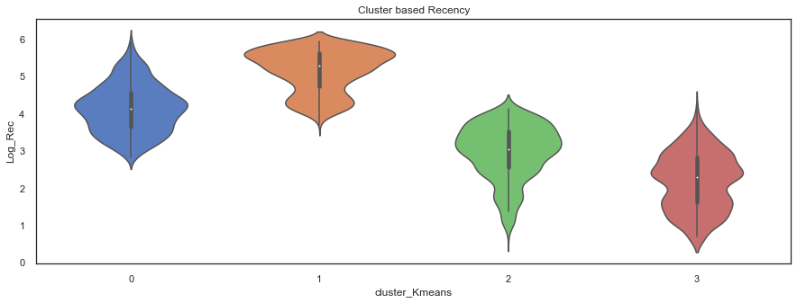

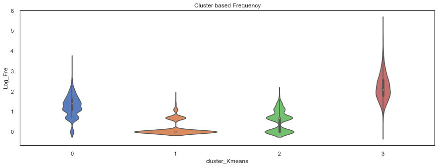

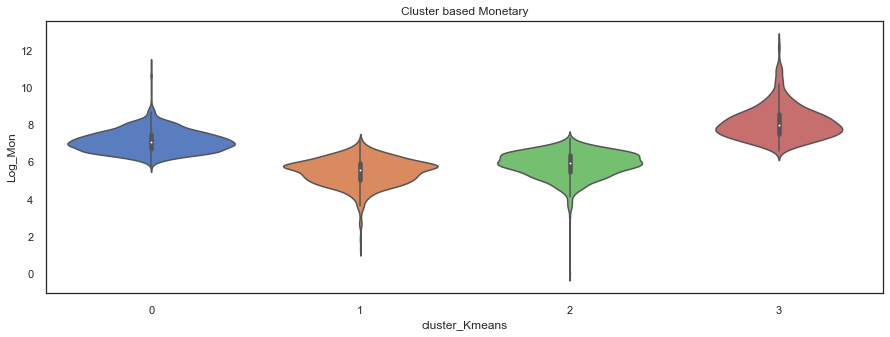

```python
plt.figure(figsize=(15,5))
sns.violinplot(RFM_df1['cluster_Kmeans'], RFM_df1['Log_Rec'])
plt.title('Cluster based Recency')
plt.show()

plt.figure(figsize=(15,5))
sns.violinplot(RFM_df1['cluster_Kmeans'], RFM_df1['Log_Fre'])
plt.title('Cluster based Frequency')
plt.show()

plt.figure(figsize=(15,5))
sns.violinplot(RFM_df1['cluster_Kmeans'], RFM_df1['Log_Mon'])
plt.title('Cluster based Monetary')
plt.show()
```

### iv. Assign the Label

- Cluster 0 : ALMOST LOST Customers
- Cluster 1 : LOST - LOST CHEAP Customers
- Cluster 2 : NORMAL Customers
- Cluster 3 : BEST-LOYAL Customers"

**Conclusion**

- Cluster 3 : belongs to the "Best Customers" segment which we saw earlier as they purchase recently (R=4), frequent buyers (F=4), and spent the most (M=4)
- cluster 2 : can be interpreted as Normal Customers.
- Cluster 1 : can be interpreted as passer customers as their last purchase is long ago (R<=1),purchased very few (F>=2 & F < 4) and spent little (M>=4 & M < 4).Company has to come up with new strategies to make them permanent members. Low value customers
- Cluster 0 : is more related to the "Almost Lost" segment as they Haven’t purchased for some time(R=1), but used to purchase frequently and spent a lot.

### v. Conclusion

Discuss your final results. Compare your own labels from the Customer Segmentation with the labels found by K-Means.

How we want to continue this analysis depends on how the business plans to use the results and the level of granularity the business stakeholders want to see in the clusters. We can also ask what range of customer behavior from high to low value customers are the stakeholders interested in exploring. From those answers, various methods of clustering can be used and applied on RFM variable or directly on the transaction data set.

**Annotation:**

Limitations of K-means clustering:

1. There is no assurance that it will lead to the global best solution.
2. Can't deal with different shapes(not circular) and consider one point's probability of belonging to more than one cluster.

These disadvantages of K-means show that for many datasets (especially low-dimensional datasets), it may not perform as well as you might hope.

# 5. Create Cohort & Conduct Cohort Analysis

[Cohort Analysis](https://medium.com/swlh/cohort-analysis-using-python-and-pandas-d2a60f4d0a4d) is specifically useful in analyzing user growth patterns for products. In terms of a product, a cohort can be a group of people with the same sign-up date, the same usage starts month/date, or the same traffic source. Cohort analysis is an analytics method by which these groups can be tracked over time for finding key insights. This analysis can further be used to do customer segmentation and track metrics like retention, churn, and lifetime value.

For e-commerce organizations, cohort analysis is a unique opportunity to find out which clients are the most valuable to their business. by performing Cohort analysis you can get the following answers to the following questions:

- How much effective was a marketing campaign held in a particular time period?
- Did the strategy employ to improve the conversion rates of Customers worked?
- Should I focus more on retention rather than acquiring new customers?
- Are my customer nurturing strategies effective?
- Which marketing channels bring me the best results?
- Is there a seasonality pattern in Customer behavior?
- Along with various performance measures/metrics for your organization.

Since we will be performing Cohort Analysis based on transaction records of customers, the columns we will be dealing with mainly:

- Invoice Data
- CustomerID
- Price
- Quantity

The following steps will performed to generate the Cohort Chart of Retention Rate:

- Month Extraction from InvioceDate column
- Assigning Cohort to Each Transaction
- Assigning Cohort Index to each transaction
- Calculating number of unique customers in each Group of (ChortDate,Index)
- Creating Cohort Table for Retention Rate
- Creating the Cohort Chart using the Cohort Table

The Detailed information about each step is given below:

## Feature Engineering

### i. Extract the Month of the Purchase

First we will create a function, which takes any date and returns the formatted date with day value as 1st of the same month and Year.

```python
df_uk2
```

|  | InvoiceNo | StockCode | Description | Quantity | InvoiceDate | UnitPrice | CustomerID | Country | Total | Quantity_Sum | Date | Recency |
| --- | --- | --- | --- | --- | --- | --- | --- | --- | --- | --- | --- | --- |
| 0 | 536365 | 85123A | WHITE HANGING HEART T-LIGHT HOLDER | 6 | 2010-12-01 08:26:00 | 2.550 | 17850 | United Kingdom | 15.300 | 34687 | 2010-12-01 | 374 |
| 1 | 536365 | 71053 | WHITE METAL LANTERN | 6 | 2010-12-01 08:26:00 | 3.390 | 17850 | United Kingdom | 20.340 | 1575 | 2010-12-01 | 374 |
| 2 | 536365 | 84406B | CREAM CUPID HEARTS COAT HANGER | 8 | 2010-12-01 08:26:00 | 2.750 | 17850 | United Kingdom | 22.000 | 1354 | 2010-12-01 | 374 |
| 3 | 536365 | 84029G | KNITTED UNION FLAG HOT WATER BOTTLE | 6 | 2010-12-01 08:26:00 | 3.390 | 17850 | United Kingdom | 20.340 | 2384 | 2010-12-01 | 374 |
| 4 | 536365 | 84029E | RED WOOLLY HOTTIE WHITE HEART. | 6 | 2010-12-01 08:26:00 | 3.390 | 17850 | United Kingdom | 20.340 | 3450 | 2010-12-01 | 374 |
| ... | ... | ... | ... | ... | ... | ... | ... | ... | ... | ... | ... | ... |
| 349222 | 581585 | 22466 | FAIRY TALE COTTAGE NIGHT LIGHT | 12 | 2011-12-09 12:31:00 | 1.950 | 15804 | United Kingdom | 23.400 | 1894 | 2011-12-09 | 2 |
| 349223 | 581586 | 22061 | LARGE CAKE STAND HANGING STRAWBERY | 8 | 2011-12-09 12:49:00 | 2.950 | 13113 | United Kingdom | 23.600 | 513 | 2011-12-09 | 2 |
| 349224 | 581586 | 23275 | SET OF 3 HANGING OWLS OLLIE BEAK | 24 | 2011-12-09 12:49:00 | 1.250 | 13113 | United Kingdom | 30.000 | 2989 | 2011-12-09 | 2 |
| 349225 | 581586 | 21217 | RED RETROSPOT ROUND CAKE TINS | 24 | 2011-12-09 12:49:00 | 8.950 | 13113 | United Kingdom | 214.800 | 570 | 2011-12-09 | 2 |
| 349226 | 581586 | 20685 | DOORMAT RED RETROSPOT | 10 | 2011-12-09 12:49:00 | 7.080 | 13113 | United Kingdom | 70.800 | 3321 | 2011-12-09 | 2 |

349227 rows × 12 columns

```python
df_uk2.info()
```

```
<class 'pandas.core.frame.DataFrame'>
Int64Index: 349227 entries, 0 to 349226
Data columns (total 12 columns):
 #   Column        Non-Null Count   Dtype
---  ------        --------------   -----
 0   InvoiceNo     349227 non-null  object
 1   StockCode     349227 non-null  object
 2   Description   349227 non-null  object
 3   Quantity      349227 non-null  int64
 4   InvoiceDate   349227 non-null  datetime64[ns]
 5   UnitPrice     349227 non-null  float64
 6   CustomerID    349227 non-null  int64
 7   Country       349227 non-null  object
 8   Total         349227 non-null  float64
 9   Quantity_Sum  349227 non-null  int64
 10  Date          349227 non-null  object
 11  Recency       349227 non-null  int32
dtypes: datetime64[ns](1), float64(2), int32(1), int64(3), object(5)
memory usage: 33.3+ MB
```

```python
df_uk2.duplicated().nunique()
```

```
1
```

```python
# df_uk3 = df_uk2[['CustomerID', 'InvoiceNo', 'InvoiceDate', 'Quantity', "UnitPrice"]]
# df_uk3.duplicated().value_counts()
```

```python
df_uk2.info()
```

[output not shown]

```python
df_uk2.head()
```

|  | InvoiceNo | StockCode | Description | Quantity | InvoiceDate | UnitPrice | CustomerID | Country | Total | Quantity_Sum | Date | Recency |
| --- | --- | --- | --- | --- | --- | --- | --- | --- | --- | --- | --- | --- |
| 0 | 536365 | 85123A | WHITE HANGING HEART T-LIGHT HOLDER | 6 | 2010-12-01 08:26:00 | 2.550 | 17850 | United Kingdom | 15.300 | 34687 | 2010-12-01 | 374 |
| 1 | 536365 | 71053 | WHITE METAL LANTERN | 6 | 2010-12-01 08:26:00 | 3.390 | 17850 | United Kingdom | 20.340 | 1575 | 2010-12-01 | 374 |
| 2 | 536365 | 84406B | CREAM CUPID HEARTS COAT HANGER | 8 | 2010-12-01 08:26:00 | 2.750 | 17850 | United Kingdom | 22.000 | 1354 | 2010-12-01 | 374 |
| 3 | 536365 | 84029G | KNITTED UNION FLAG HOT WATER BOTTLE | 6 | 2010-12-01 08:26:00 | 3.390 | 17850 | United Kingdom | 20.340 | 2384 | 2010-12-01 | 374 |
| 4 | 536365 | 84029E | RED WOOLLY HOTTIE WHITE HEART. | 6 | 2010-12-01 08:26:00 | 3.390 | 17850 | United Kingdom | 20.340 | 3450 | 2010-12-01 | 374 |

```python
cohort_df = df_uk2.drop(["Total", "Quantity_Sum", "Date", "Recency"], axis=1)
cohort_df.head()
```

|  | InvoiceNo | StockCode | Description | Quantity | InvoiceDate | UnitPrice | CustomerID | Country |
| --- | --- | --- | --- | --- | --- | --- | --- | --- |
| 0 | 536365 | 85123A | WHITE HANGING HEART T-LIGHT HOLDER | 6 | 2010-12-01 08:26:00 | 2.550 | 17850 | United Kingdom |
| 1 | 536365 | 71053 | WHITE METAL LANTERN | 6 | 2010-12-01 08:26:00 | 3.390 | 17850 | United Kingdom |
| 2 | 536365 | 84406B | CREAM CUPID HEARTS COAT HANGER | 8 | 2010-12-01 08:26:00 | 2.750 | 17850 | United Kingdom |
| 3 | 536365 | 84029G | KNITTED UNION FLAG HOT WATER BOTTLE | 6 | 2010-12-01 08:26:00 | 3.390 | 17850 | United Kingdom |
| 4 | 536365 | 84029E | RED WOOLLY HOTTIE WHITE HEART. | 6 | 2010-12-01 08:26:00 | 3.390 | 17850 | United Kingdom |

```python
cohort_df.shape
```

```
(349227, 8)
```

```python
cohort_df.duplicated().nunique()  # There is no duplicates and dataset is ready for coohor analysis
```

```
1
```

*Checking the date range of our data, we find that it ranges from the start date: 2010–12–01 to the end date: 2011–12–09. Next, a column called InvoiceMonth will be created to indicate the month of the transaction by taking the first date of the month of InvoiceDate for each transaction. Then, information about the first month of the transaction will be extracted, grouped by the CustomerID.*

```python
# Another way of taking Month and Year

# df_uk3['order_month'] = df_uk3['InvoiceDate'].dt.to_period('M')
# df_uk3['cohort'] = df_uk3.groupby('CustomerID')['InvoiceDate'].transform('min').dt.to_period('M')
# df_uk3
```

```python
import datetime as dt
```

```python
def get_month(x):
    return dt.datetime(x.year, x.month, 1)
```

Now we will use the function created above to convert all the invoice dates into respective month date format.

```python
cohort_df['InvoiceMonth'] = cohort_df['InvoiceDate'].apply(get_month)
cohort_df['CohortMonth'] = cohort_df.groupby('CustomerID')['InvoiceMonth'].transform('min')
cohort_df.head()
```

|  | InvoiceNo | StockCode | Description | Quantity | InvoiceDate | UnitPrice | CustomerID | Country | InvoiceMonth | CohortMonth |
| --- | --- | --- | --- | --- | --- | --- | --- | --- | --- | --- |
| 0 | 536365 | 85123A | WHITE HANGING HEART T-LIGHT HOLDER | 6 | 2010-12-01 08:26:00 | 2.550 | 17850 | United Kingdom | 2010-12-01 | 2010-12-01 |
| 1 | 536365 | 71053 | WHITE METAL LANTERN | 6 | 2010-12-01 08:26:00 | 3.390 | 17850 | United Kingdom | 2010-12-01 | 2010-12-01 |
| 2 | 536365 | 84406B | CREAM CUPID HEARTS COAT HANGER | 8 | 2010-12-01 08:26:00 | 2.750 | 17850 | United Kingdom | 2010-12-01 | 2010-12-01 |
| 3 | 536365 | 84029G | KNITTED UNION FLAG HOT WATER BOTTLE | 6 | 2010-12-01 08:26:00 | 3.390 | 17850 | United Kingdom | 2010-12-01 | 2010-12-01 |
| 4 | 536365 | 84029E | RED WOOLLY HOTTIE WHITE HEART. | 6 | 2010-12-01 08:26:00 | 3.390 | 17850 | United Kingdom | 2010-12-01 | 2010-12-01 |

```python
cohort_df.sample(10)
```

|  | InvoiceNo | StockCode | Description | Quantity | InvoiceDate | UnitPrice | CustomerID | Country | InvoiceMonth | CohortMonth |
| --- | --- | --- | --- | --- | --- | --- | --- | --- | --- | --- |
| 332094 | 578901 | 21098 | CHRISTMAS TOILET ROLL | 1 | 2011-11-27 11:47:00 | 1.250 | 17812 | United Kingdom | 2011-11-01 | 2010-12-01 |
| 305990 | 576076 | 20981 | 12 PENCILS TALL TUBE WOODLAND | 1 | 2011-11-13 16:18:00 | 0.850 | 14382 | United Kingdom | 2011-11-01 | 2011-11-01 |
| 220136 | 567160 | 21216 | SET 3 RETROSPOT TEA,COFFEE,SUGAR | 1 | 2011-09-18 10:35:00 | 4.950 | 14562 | United Kingdom | 2011-09-01 | 2011-02-01 |
| 66293 | 545998 | 22505 | MEMO BOARD COTTAGE DESIGN | 12 | 2011-03-08 14:35:00 | 4.950 | 13373 | United Kingdom | 2011-03-01 | 2011-03-01 |
| 193703 | 563738 | 22457 | NATURAL SLATE HEART CHALKBOARD | 2 | 2011-08-18 19:13:00 | 2.950 | 15024 | United Kingdom | 2011-08-01 | 2010-12-01 |
| 60082 | 545164 | 22356 | CHARLOTTE BAG PINK POLKADOT | 10 | 2011-02-28 13:40:00 | 0.850 | 16458 | United Kingdom | 2011-02-01 | 2010-12-01 |
| 334974 | 579136 | 22961 | JAM MAKING SET PRINTED | 12 | 2011-11-28 12:45:00 | 1.450 | 16094 | United Kingdom | 2011-11-01 | 2011-05-01 |
| 57253 | 544836 | 22919 | HERB MARKER MINT | 12 | 2011-02-24 10:25:00 | 0.650 | 17613 | United Kingdom | 2011-02-01 | 2011-02-01 |
| 65839 | 545933 | 16161P | WRAP ENGLISH ROSE | 25 | 2011-03-08 12:04:00 | 0.420 | 13908 | United Kingdom | 2011-03-01 | 2011-03-01 |
| 302351 | 575848 | 22138 | BAKING SET 9 PIECE RETROSPOT | 1 | 2011-11-11 12:10:00 | 4.950 | 14178 | United Kingdom | 2011-11-01 | 2011-06-01 |

*Next, we need to find the difference between the InvoiceMonth and the CohortMonth column in terms of the number of months.*

### ii. Calculating time offset in Months i.e. Cohort Index:

Calculating time offset for each transaction will allows us to report the metrics for each cohort in a comparable fashion. First, you will create 4 variables that capture the integer value of years, months for Invoice and Cohort Date using the get_date_int() function which you'll create it below.

```python
cohort_df.sample(10).InvoiceMonth.dt.year  # this gives a series of year
```

```
240435    2011
105526    2011
45080     2011
258328    2011
65641     2011
211490    2011
305778    2011
289239    2011
110827    2011
299712    2011
Name: InvoiceMonth, dtype: int64
```

```python
cohort_df.InvoiceMonth.dt.month  # this gives a series of year
```

```
0         12
1         12
2         12
3         12
4         12
          ..
349222    12
349223    12
349224    12
349225    12
349226    12
Name: InvoiceMonth, Length: 349227, dtype: int64
```

```python
def get_date_int(df, column):
    year = df[column].dt.year
    month = df[column].dt.month
    day = df[column].dt.day
    return year, month, day
```

We will use this function to extract the integer values for Invoice as well as Cohort Date in 3 seperate series for each of the two columns

```python
invoice_year, invoice_month, _ = get_date_int(cohort_df, 'InvoiceMonth')  # results are pandas series
cohort_year, cohort_month, _ = get_date_int(cohort_df, 'CohortMonth')
```

```python
# results are also pandas series
years_diff = invoice_year - cohort_year
months_diff = invoice_month - cohort_month
cohort_df['CohortIndex'] = years_diff * 12 + months_diff  # the diffrence
cohort_df.head()
```

|  | InvoiceNo | StockCode | Description | Quantity | InvoiceDate | UnitPrice | CustomerID | Country | InvoiceMonth | CohortMonth | CohortIndex |
| --- | --- | --- | --- | --- | --- | --- | --- | --- | --- | --- | --- |
| 0 | 536365 | 85123A | WHITE HANGING HEART T-LIGHT HOLDER | 6 | 2010-12-01 08:26:00 | 2.550 | 17850 | United Kingdom | 2010-12-01 | 2010-12-01 | 0 |
| 1 | 536365 | 71053 | WHITE METAL LANTERN | 6 | 2010-12-01 08:26:00 | 3.390 | 17850 | United Kingdom | 2010-12-01 | 2010-12-01 | 0 |
| 2 | 536365 | 84406B | CREAM CUPID HEARTS COAT HANGER | 8 | 2010-12-01 08:26:00 | 2.750 | 17850 | United Kingdom | 2010-12-01 | 2010-12-01 | 0 |
| 3 | 536365 | 84029G | KNITTED UNION FLAG HOT WATER BOTTLE | 6 | 2010-12-01 08:26:00 | 3.390 | 17850 | United Kingdom | 2010-12-01 | 2010-12-01 | 0 |
| 4 | 536365 | 84029E | RED WOOLLY HOTTIE WHITE HEART. | 6 | 2010-12-01 08:26:00 | 3.390 | 17850 | United Kingdom | 2010-12-01 | 2010-12-01 | 0 |

```python
cohort_df.sample(5)
```

|  | InvoiceNo | StockCode | Description | Quantity | InvoiceDate | UnitPrice | CustomerID | Country | InvoiceMonth | CohortMonth | CohortIndex |
| --- | --- | --- | --- | --- | --- | --- | --- | --- | --- | --- | --- |
| 76209 | 547651 | 21158 | MOODY GIRL DOOR HANGER | 1 | 2011-03-24 12:11:00 | 1.450 | 16904 | United Kingdom | 2011-03-01 | 2010-12-01 | 3 |
| 4057 | 536946 | 21212 | PACK OF 72 RETROSPOT CAKE CASES | 24 | 2010-12-03 12:28:00 | 0.550 | 13013 | United Kingdom | 2010-12-01 | 2010-12-01 | 0 |
| 313577 | 577602 | 23298 | SPOTTY BUNTING | 6 | 2011-11-21 08:37:00 | 4.950 | 16139 | United Kingdom | 2011-11-01 | 2011-05-01 | 6 |
| 265849 | 572661 | 22530 | MAGIC DRAWING SLATE DOLLY GIRL | 72 | 2011-10-25 12:38:00 | 0.420 | 17193 | United Kingdom | 2011-10-01 | 2011-06-01 | 4 |
| 142272 | 557218 | 23188 | VINTAGE 2 METER FOLDING RULER | 12 | 2011-06-17 12:31:00 | 1.650 | 17426 | United Kingdom | 2011-06-01 | 2011-03-01 | 3 |

## Create 1st Cohort: User number & Retention Rate

### i. Pivot Cohort and Cohort Retention

*After obtaining the above information, we obtain the cohort analysis matrix by grouping the data by CohortMonth and CohortIndex and aggregating on the CustomerID column by applying the pd.Series.nunique function. Here is the pivot cohort:*

```python
first_df = cohort_df.groupby(["CohortMonth", "CohortIndex"], as_index= False)["CustomerID"].nunique()
first_df
```

|  | CohortMonth | CohortIndex | CustomerID |
| --- | --- | --- | --- |
| 0 | 2010-12-01 | 0 | 815 |
| 1 | 2010-12-01 | 1 | 289 |
| 2 | 2010-12-01 | 2 | 263 |
| 3 | 2010-12-01 | 3 | 304 |
| 4 | 2010-12-01 | 4 | 293 |
| ... | ... | ... | ... |
| 86 | 2011-10-01 | 1 | 79 |
| 87 | 2011-10-01 | 2 | 36 |
| 88 | 2011-11-01 | 0 | 298 |
| 89 | 2011-11-01 | 1 | 35 |
| 90 | 2011-12-01 | 0 | 34 |

91 rows × 3 columns

```python
# decimal number formatting
pd.options.display.float_format = '{:,.1f}'.format
```

```python
pivoted_df = first_df.pivot(index="CohortMonth", columns="CohortIndex", values="CustomerID")
pivoted_df
```

| CohortIndex CohortMonth | 0 | 1 | 2 | 3 | 4 | 5 | 6 | 7 | 8 | 9 | 10 | 11 | 12 |
| --- | --- | --- | --- | --- | --- | --- | --- | --- | --- | --- | --- | --- | --- |
| 2010-12-01 | 815.0 | 289.0 | 263.0 | 304.0 | 293.0 | 323.0 | 291.0 | 278.0 | 289.0 | 325.0 | 299.0 | 405.0 | 218.0 |
| 2011-01-01 | 358.0 | 76.0 | 93.0 | 84.0 | 119.0 | 99.0 | 90.0 | 87.0 | 108.0 | 117.0 | 127.0 | 43.0 | nan |
| 2011-02-01 | 340.0 | 64.0 | 66.0 | 97.0 | 98.0 | 86.0 | 87.0 | 96.0 | 90.0 | 104.0 | 25.0 | nan | nan |
| 2011-03-01 | 419.0 | 64.0 | 109.0 | 83.0 | 94.0 | 69.0 | 111.0 | 96.0 | 119.0 | 38.0 | nan | nan | nan |
| 2011-04-01 | 277.0 | 58.0 | 56.0 | 60.0 | 56.0 | 61.0 | 61.0 | 73.0 | 20.0 | nan | nan | nan | nan |
| 2011-05-01 | 256.0 | 48.0 | 44.0 | 44.0 | 53.0 | 58.0 | 68.0 | 23.0 | nan | nan | nan | nan | nan |
| 2011-06-01 | 214.0 | 38.0 | 31.0 | 51.0 | 51.0 | 69.0 | 21.0 | nan | nan | nan | nan | nan | nan |
| 2011-07-01 | 169.0 | 30.0 | 33.0 | 39.0 | 47.0 | 18.0 | nan | nan | nan | nan | nan | nan | nan |
| 2011-08-01 | 141.0 | 32.0 | 32.0 | 34.0 | 17.0 | nan | nan | nan | nan | nan | nan | nan | nan |
| 2011-09-01 | 276.0 | 63.0 | 83.0 | 32.0 | nan | nan | nan | nan | nan | nan | nan | nan | nan |
| 2011-10-01 | 324.0 | 79.0 | 36.0 | nan | nan | nan | nan | nan | nan | nan | nan | nan | nan |
| 2011-11-01 | 298.0 | 35.0 | nan | nan | nan | nan | nan | nan | nan | nan | nan | nan | nan |
| 2011-12-01 | 34.0 | nan | nan | nan | nan | nan | nan | nan | nan | nan | nan | nan | nan |

*What does the above table tell us?*

*Consider CohortMonth 2010–12–01: For CohortIndex 0, this tells us that 815 unique customers made transactions during CohortMonth 2010–12–01. For CohortIndex 1, this tells that there are 289 customers out of 815 who made their first transaction during CohortMonth 2010–12–01 and they also made transactions during the next month. That is, they remained active. For CohortIndex 2, this tells that there are 263 customers out of 815 who made their first transaction during CohortMonth 2010–12–01 and they also made transactions during the second-next month. And so on for higher CohortIndices.*

### ii. Visualize analysis of cohort 1 using seaborn and matplotlib modules

*Let us now calculate the Retention Rate. It is defined as the percentage of active customers out of total customers. Since the number of active customers in each cohort corresponds to the CohortIndex 0 values, we take the first column of the data as the cohort sizes.*

```python
cohort_sizes = pivoted_df.iloc[:,0]
cohort_sizes
```

```
CohortMonth
2010-12-01   815.0
2011-01-01   358.0
2011-02-01   340.0
2011-03-01   419.0
2011-04-01   277.0
2011-05-01   256.0
2011-06-01   214.0
2011-07-01   169.0
2011-08-01   141.0
2011-09-01   276.0
2011-10-01   324.0
2011-11-01   298.0
2011-12-01    34.0
Name: 0, dtype: float64
```

```python
# Divide all values in the pivoted_df table by cohort_sizes
retention = pivoted_df.divide(cohort_sizes, axis=0)
retention
```

| CohortIndex CohortMonth | 0 | 1 | 2 | 3 | 4 | 5 | 6 | 7 | 8 | 9 | 10 | 11 | 12 |
| --- | --- | --- | --- | --- | --- | --- | --- | --- | --- | --- | --- | --- | --- |
| 2010-12-01 | 1.0 | 0.4 | 0.3 | 0.4 | 0.4 | 0.4 | 0.4 | 0.3 | 0.4 | 0.4 | 0.4 | 0.5 | 0.3 |
| 2011-01-01 | 1.0 | 0.2 | 0.3 | 0.2 | 0.3 | 0.3 | 0.3 | 0.2 | 0.3 | 0.3 | 0.4 | 0.1 | nan |
| 2011-02-01 | 1.0 | 0.2 | 0.2 | 0.3 | 0.3 | 0.3 | 0.3 | 0.3 | 0.3 | 0.3 | 0.1 | nan | nan |
| 2011-03-01 | 1.0 | 0.2 | 0.3 | 0.2 | 0.2 | 0.2 | 0.3 | 0.2 | 0.3 | 0.1 | nan | nan | nan |
| 2011-04-01 | 1.0 | 0.2 | 0.2 | 0.2 | 0.2 | 0.2 | 0.2 | 0.3 | 0.1 | nan | nan | nan | nan |
| 2011-05-01 | 1.0 | 0.2 | 0.2 | 0.2 | 0.2 | 0.2 | 0.3 | 0.1 | nan | nan | nan | nan | nan |
| 2011-06-01 | 1.0 | 0.2 | 0.1 | 0.2 | 0.2 | 0.3 | 0.1 | nan | nan | nan | nan | nan | nan |
| 2011-07-01 | 1.0 | 0.2 | 0.2 | 0.2 | 0.3 | 0.1 | nan | nan | nan | nan | nan | nan | nan |
| 2011-08-01 | 1.0 | 0.2 | 0.2 | 0.2 | 0.1 | nan | nan | nan | nan | nan | nan | nan | nan |
| 2011-09-01 | 1.0 | 0.2 | 0.3 | 0.1 | nan | nan | nan | nan | nan | nan | nan | nan | nan |
| 2011-10-01 | 1.0 | 0.2 | 0.1 | nan | nan | nan | nan | nan | nan | nan | nan | nan | nan |
| 2011-11-01 | 1.0 | 0.1 | nan | nan | nan | nan | nan | nan | nan | nan | nan | nan | nan |
| 2011-12-01 | 1.0 | nan | nan | nan | nan | nan | nan | nan | nan | nan | nan | nan | nan |

```python
# Check the retention table
retention.round(3) * 100
```

| CohortIndex CohortMonth | 0 | 1 | 2 | 3 | 4 | 5 | 6 | 7 | 8 | 9 | 10 | 11 | 12 |
| --- | --- | --- | --- | --- | --- | --- | --- | --- | --- | --- | --- | --- | --- |
| 2010-12-01 | 100.0 | 35.5 | 32.3 | 37.3 | 36.0 | 39.6 | 35.7 | 34.1 | 35.5 | 39.9 | 36.7 | 49.7 | 26.7 |
| 2011-01-01 | 100.0 | 21.2 | 26.0 | 23.5 | 33.2 | 27.7 | 25.1 | 24.3 | 30.2 | 32.7 | 35.5 | 12.0 | nan |
| 2011-02-01 | 100.0 | 18.8 | 19.4 | 28.5 | 28.8 | 25.3 | 25.6 | 28.2 | 26.5 | 30.6 | 7.4 | nan | nan |
| 2011-03-01 | 100.0 | 15.3 | 26.0 | 19.8 | 22.4 | 16.5 | 26.5 | 22.9 | 28.4 | 9.1 | nan | nan | nan |
| 2011-04-01 | 100.0 | 20.9 | 20.2 | 21.7 | 20.2 | 22.0 | 22.0 | 26.4 | 7.2 | nan | nan | nan | nan |
| 2011-05-01 | 100.0 | 18.8 | 17.2 | 17.2 | 20.7 | 22.7 | 26.6 | 9.0 | nan | nan | nan | nan | nan |
| 2011-06-01 | 100.0 | 17.8 | 14.5 | 23.8 | 23.8 | 32.2 | 9.8 | nan | nan | nan | nan | nan | nan |
| 2011-07-01 | 100.0 | 17.8 | 19.5 | 23.1 | 27.8 | 10.7 | nan | nan | nan | nan | nan | nan | nan |
| 2011-08-01 | 100.0 | 22.7 | 22.7 | 24.1 | 12.1 | nan | nan | nan | nan | nan | nan | nan | nan |
| 2011-09-01 | 100.0 | 22.8 | 30.1 | 11.6 | nan | nan | nan | nan | nan | nan | nan | nan | nan |
| 2011-10-01 | 100.0 | 24.4 | 11.1 | nan | nan | nan | nan | nan | nan | nan | nan | nan | nan |
| 2011-11-01 | 100.0 | 11.7 | nan | nan | nan | nan | nan | nan | nan | nan | nan | nan | nan |
| 2011-12-01 | 100.0 | nan | nan | nan | nan | nan | nan | nan | nan | nan | nan | nan | nan |

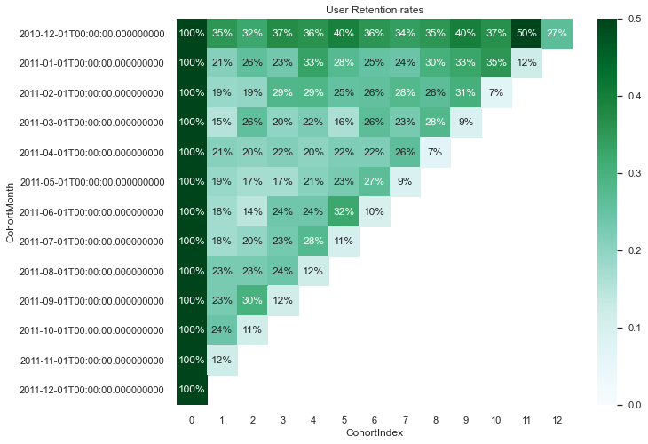

```python
# Drawing a heatmap
plt.figure(figsize=(10, 8))
sns.heatmap(data = retention, annot = True, fmt = '.0%', vmin = 0.0, vmax = 0.5, cmap = 'BuGn')
plt.title('User Retention rates')
plt.show()
```

*From the above retention rate heatmap, we can see that there is an average retention of ~35% for the CohortMonth 2010–12–01, with the highest retention rate occurring after 11 months (50%). For all the other CohortMonths, the average retention rates are around 18–25%. Only this percentage of users are making transactions again in the given CohortIndex ranges. From this analysis, we can create strategies to increase customer retention by providing more attractive discounts and by doing more effective marketing.*

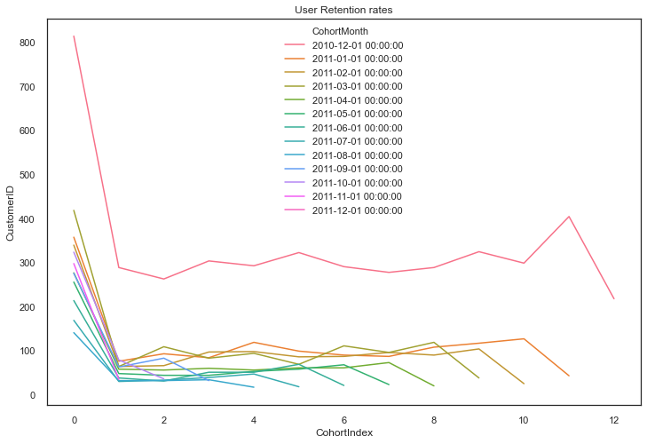

```python
# Drawing a chart
plt.figure(figsize=(12, 8))
sns.lineplot(x="CohortIndex", y="CustomerID", hue= "CohortMonth", data = first_df)
plt.title('User Retention rates')
plt.show()
```

*In the chart above, you can see the retention based on the number of paying users in each cohort across the months.*

## Create the 2nd Cohort: Average Quantity Sold

### i. Pivot Cohort and Cohort Retention

*Now, we will obtain the cohort analysis matrix by grouping the data by CohortMonth and CohortIndex and aggregating on the Quantity column by applying the pd.Series.sum() function. Here is the pivot cohort:*

```python
second_df = cohort_df.groupby(["CohortMonth", "CohortIndex"], as_index= False)["Quantity"].sum()
second_df
```

|  | CohortMonth | CohortIndex | Quantity |
| --- | --- | --- | --- |
| 0 | 2010-12-01 | 0 | 266577 |
| 1 | 2010-12-01 | 1 | 114201 |
| 2 | 2010-12-01 | 2 | 106823 |
| 3 | 2010-12-01 | 3 | 134817 |
| 4 | 2010-12-01 | 4 | 116491 |
| ... | ... | ... | ... |
| 86 | 2011-10-01 | 1 | 24551 |
| 87 | 2011-10-01 | 2 | 6429 |
| 88 | 2011-11-01 | 0 | 90176 |
| 89 | 2011-11-01 | 1 | 9998 |
| 90 | 2011-12-01 | 0 | 12993 |

91 rows × 3 columns

```python
pivoted2_df = second_df.pivot(index="CohortMonth", columns="CohortIndex", values="Quantity")
pivoted2_df
```

| CohortIndex CohortMonth | 0 | 1 | 2 | 3 | 4 | 5 | 6 | 7 | 8 | 9 | 10 | 11 | 12 |
| --- | --- | --- | --- | --- | --- | --- | --- | --- | --- | --- | --- | --- | --- |
| 2010-12-01 | 266,577.0 | 114,201.0 | 106,823.0 | 134,817.0 | 116,491.0 | 139,019.0 | 137,367.0 | 136,477.0 | 159,655.0 | 195,245.0 | 188,766.0 | 239,005.0 | 91,879.0 |
| 2011-01-01 | 163,498.0 | 18,073.0 | 24,096.0 | 31,767.0 | 31,732.0 | 28,587.0 | 31,976.0 | 25,912.0 | 36,383.0 | 36,582.0 | 48,023.0 | 12,668.0 | nan |
| 2011-02-01 | 87,912.0 | 18,012.0 | 28,628.0 | 27,796.0 | 27,118.0 | 22,759.0 | 27,550.0 | 34,250.0 | 30,615.0 | 32,774.0 | 5,818.0 | nan | nan |
| 2011-03-01 | 98,501.0 | 15,774.0 | 33,516.0 | 21,687.0 | 30,598.0 | 24,289.0 | 35,862.0 | 44,197.0 | 45,202.0 | 9,335.0 | nan | nan | nan |
| 2011-04-01 | 66,934.0 | 13,153.0 | 11,626.0 | 14,723.0 | 15,245.0 | 14,583.0 | 17,783.0 | 18,915.0 | 3,522.0 | nan | nan | nan | nan |
| 2011-05-01 | 55,901.0 | 9,205.0 | 11,339.0 | 10,509.0 | 15,243.0 | 15,519.0 | 18,009.0 | 85,792.0 | nan | nan | nan | nan | nan |
| 2011-06-01 | 44,731.0 | 11,799.0 | 6,074.0 | 15,413.0 | 15,375.0 | 19,667.0 | 5,526.0 | nan | nan | nan | nan | nan | nan |
| 2011-07-01 | 41,882.0 | 5,829.0 | 7,585.0 | 9,751.0 | 9,251.0 | 3,061.0 | nan | nan | nan | nan | nan | nan | nan |
| 2011-08-01 | 35,039.0 | 9,279.0 | 13,405.0 | 15,636.0 | 5,457.0 | nan | nan | nan | nan | nan | nan | nan | nan |
| 2011-09-01 | 89,579.0 | 13,403.0 | 19,563.0 | 7,493.0 | nan | nan | nan | nan | nan | nan | nan | nan | nan |
| 2011-10-01 | 89,279.0 | 24,551.0 | 6,429.0 | nan | nan | nan | nan | nan | nan | nan | nan | nan | nan |
| 2011-11-01 | 90,176.0 | 9,998.0 | nan | nan | nan | nan | nan | nan | nan | nan | nan | nan | nan |
| 2011-12-01 | 12,993.0 | nan | nan | nan | nan | nan | nan | nan | nan | nan | nan | nan | nan |

```python
cohort_sizes = pivoted2_df.iloc[:,0]
cohort_sizes
```

```
CohortMonth
2010-12-01   266,577.0
2011-01-01   163,498.0
2011-02-01    87,912.0
2011-03-01    98,501.0
2011-04-01    66,934.0
2011-05-01    55,901.0
2011-06-01    44,731.0
2011-07-01    41,882.0
2011-08-01    35,039.0
2011-09-01    89,579.0
2011-10-01    89,279.0
2011-11-01    90,176.0
2011-12-01    12,993.0
Name: 0, dtype: float64
```

```python
retention2 = pivoted2_df.divide(cohort_sizes, axis=0)
retention2
```

| CohortIndex CohortMonth | 0 | 1 | 2 | 3 | 4 | 5 | 6 | 7 | 8 | 9 | 10 | 11 | 12 |
| --- | --- | --- | --- | --- | --- | --- | --- | --- | --- | --- | --- | --- | --- |
| 2010-12-01 | 1.0 | 0.4 | 0.4 | 0.5 | 0.4 | 0.5 | 0.5 | 0.5 | 0.6 | 0.7 | 0.7 | 0.9 | 0.3 |
| 2011-01-01 | 1.0 | 0.1 | 0.1 | 0.2 | 0.2 | 0.2 | 0.2 | 0.2 | 0.2 | 0.2 | 0.3 | 0.1 | nan |
| 2011-02-01 | 1.0 | 0.2 | 0.3 | 0.3 | 0.3 | 0.3 | 0.3 | 0.4 | 0.3 | 0.4 | 0.1 | nan | nan |
| 2011-03-01 | 1.0 | 0.2 | 0.3 | 0.2 | 0.3 | 0.2 | 0.4 | 0.4 | 0.5 | 0.1 | nan | nan | nan |
| 2011-04-01 | 1.0 | 0.2 | 0.2 | 0.2 | 0.2 | 0.2 | 0.3 | 0.3 | 0.1 | nan | nan | nan | nan |
| 2011-05-01 | 1.0 | 0.2 | 0.2 | 0.2 | 0.3 | 0.3 | 0.3 | 1.5 | nan | nan | nan | nan | nan |
| 2011-06-01 | 1.0 | 0.3 | 0.1 | 0.3 | 0.3 | 0.4 | 0.1 | nan | nan | nan | nan | nan | nan |
| 2011-07-01 | 1.0 | 0.1 | 0.2 | 0.2 | 0.2 | 0.1 | nan | nan | nan | nan | nan | nan | nan |
| 2011-08-01 | 1.0 | 0.3 | 0.4 | 0.4 | 0.2 | nan | nan | nan | nan | nan | nan | nan | nan |
| 2011-09-01 | 1.0 | 0.1 | 0.2 | 0.1 | nan | nan | nan | nan | nan | nan | nan | nan | nan |
| 2011-10-01 | 1.0 | 0.3 | 0.1 | nan | nan | nan | nan | nan | nan | nan | nan | nan | nan |
| 2011-11-01 | 1.0 | 0.1 | nan | nan | nan | nan | nan | nan | nan | nan | nan | nan | nan |
| 2011-12-01 | 1.0 | nan | nan | nan | nan | nan | nan | nan | nan | nan | nan | nan | nan |

```python
retention2.round(3) * 100
```

| CohortIndex CohortMonth | 0 | 1 | 2 | 3 | 4 | 5 | 6 | 7 | 8 | 9 | 10 | 11 | 12 |
| --- | --- | --- | --- | --- | --- | --- | --- | --- | --- | --- | --- | --- | --- |
| 2010-12-01 | 100.0 | 42.8 | 40.1 | 50.6 | 43.7 | 52.1 | 51.5 | 51.2 | 59.9 | 73.2 | 70.8 | 89.7 | 34.5 |
| 2011-01-01 | 100.0 | 11.1 | 14.7 | 19.4 | 19.4 | 17.5 | 19.6 | 15.8 | 22.3 | 22.4 | 29.4 | 7.7 | nan |
| 2011-02-01 | 100.0 | 20.5 | 32.6 | 31.6 | 30.8 | 25.9 | 31.3 | 39.0 | 34.8 | 37.3 | 6.6 | nan | nan |
| 2011-03-01 | 100.0 | 16.0 | 34.0 | 22.0 | 31.1 | 24.7 | 36.4 | 44.9 | 45.9 | 9.5 | nan | nan | nan |
| 2011-04-01 | 100.0 | 19.7 | 17.4 | 22.0 | 22.8 | 21.8 | 26.6 | 28.3 | 5.3 | nan | nan | nan | nan |
| 2011-05-01 | 100.0 | 16.5 | 20.3 | 18.8 | 27.3 | 27.8 | 32.2 | 153.5 | nan | nan | nan | nan | nan |
| 2011-06-01 | 100.0 | 26.4 | 13.6 | 34.5 | 34.4 | 44.0 | 12.4 | nan | nan | nan | nan | nan | nan |
| 2011-07-01 | 100.0 | 13.9 | 18.1 | 23.3 | 22.1 | 7.3 | nan | nan | nan | nan | nan | nan | nan |
| 2011-08-01 | 100.0 | 26.5 | 38.3 | 44.6 | 15.6 | nan | nan | nan | nan | nan | nan | nan | nan |
| 2011-09-01 | 100.0 | 15.0 | 21.8 | 8.4 | nan | nan | nan | nan | nan | nan | nan | nan | nan |
| 2011-10-01 | 100.0 | 27.5 | 7.2 | nan | nan | nan | nan | nan | nan | nan | nan | nan | nan |
| 2011-11-01 | 100.0 | 11.1 | nan | nan | nan | nan | nan | nan | nan | nan | nan | nan | nan |
| 2011-12-01 | 100.0 | nan | nan | nan | nan | nan | nan | nan | nan | nan | nan | nan | nan |

### ii. Visualize analysis of cohort 2 using seaborn and matplotlib modules

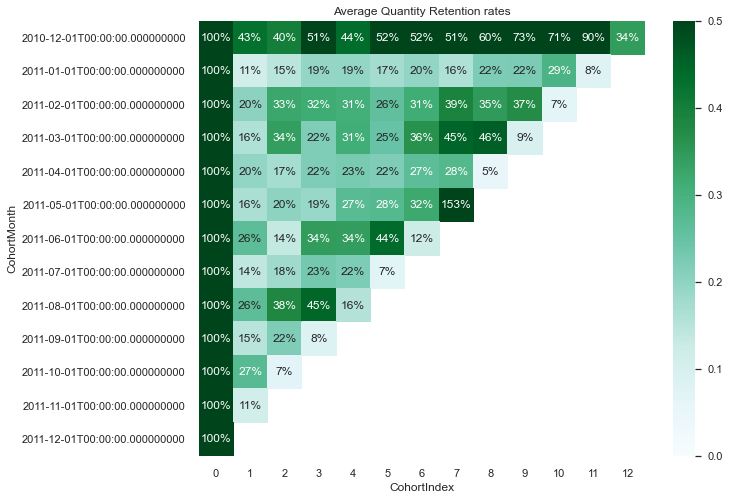

```python
# Drawing a heatmap
plt.figure(figsize=(10, 8))
sns.heatmap(data = retention2, annot = True, fmt = '.0%', vmin = 0.0, vmax = 0.5, cmap = 'BuGn')
plt.title('Average Quantity Retention rates')
plt.show()
```

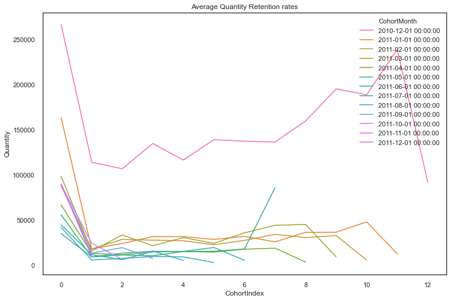

```python
# Drawing a chart
plt.figure(figsize=(12, 8))
sns.lineplot(x="CohortIndex", y="Quantity", hue= "CohortMonth", data = second_df)
plt.title('Average Quantity Retention rates')
plt.show()
```

*In the chart above, you can see the retention based on the average quantity sold in each cohort across the months.*

## Create the 3rd Cohort: Average Sales

### i. Pivot Cohort and Cohort Retention

```python
cohort_df["TotalSales"] = cohort_df["Quantity"] * cohort_df["UnitPrice"]
cohort_df.head()
```

|  | InvoiceNo | StockCode | Description | Quantity | InvoiceDate | UnitPrice | CustomerID | Country | InvoiceMonth | CohortMonth | CohortIndex | TotalSales |
| --- | --- | --- | --- | --- | --- | --- | --- | --- | --- | --- | --- | --- |
| 0 | 536365 | 85123A | WHITE HANGING HEART T-LIGHT HOLDER | 6 | 2010-12-01 08:26:00 | 2.5 | 17850 | United Kingdom | 2010-12-01 | 2010-12-01 | 0 | 15.3 |
| 1 | 536365 | 71053 | WHITE METAL LANTERN | 6 | 2010-12-01 08:26:00 | 3.4 | 17850 | United Kingdom | 2010-12-01 | 2010-12-01 | 0 | 20.3 |
| 2 | 536365 | 84406B | CREAM CUPID HEARTS COAT HANGER | 8 | 2010-12-01 08:26:00 | 2.8 | 17850 | United Kingdom | 2010-12-01 | 2010-12-01 | 0 | 22.0 |
| 3 | 536365 | 84029G | KNITTED UNION FLAG HOT WATER BOTTLE | 6 | 2010-12-01 08:26:00 | 3.4 | 17850 | United Kingdom | 2010-12-01 | 2010-12-01 | 0 | 20.3 |
| 4 | 536365 | 84029E | RED WOOLLY HOTTIE WHITE HEART. | 6 | 2010-12-01 08:26:00 | 3.4 | 17850 | United Kingdom | 2010-12-01 | 2010-12-01 | 0 | 20.3 |

*Now, we will obtain the cohort analysis matrix by grouping the data by CohortMonth and CohortIndex and aggregating on the TotalSales column by applying the pd.Series.sum() function. Here is the pivot cohort:*

```python
third_df = cohort_df.groupby(["CohortMonth", "CohortIndex"], as_index= False)["TotalSales"].sum()
third_df
```

|  | CohortMonth | CohortIndex | TotalSales |
| --- | --- | --- | --- |
| 0 | 2010-12-01 | 0 | 496,477.3 |
| 1 | 2010-12-01 | 1 | 199,116.7 |
| 2 | 2010-12-01 | 2 | 183,772.6 |
| 3 | 2010-12-01 | 3 | 230,890.8 |
| 4 | 2010-12-01 | 4 | 176,777.0 |
| ... | ... | ... | ... |
| 86 | 2011-10-01 | 1 | 37,813.9 |
| 87 | 2011-10-01 | 2 | 10,810.4 |
| 88 | 2011-11-01 | 0 | 117,535.5 |
| 89 | 2011-11-01 | 1 | 13,786.4 |
| 90 | 2011-12-01 | 0 | 24,406.6 |

91 rows × 3 columns

```python
pivoted3_df = third_df.pivot(index="CohortMonth", columns="CohortIndex", values="TotalSales")
pivoted3_df
```

| CohortIndex CohortMonth | 0 | 1 | 2 | 3 | 4 | 5 | 6 | 7 | 8 | 9 | 10 | 11 | 12 |
| --- | --- | --- | --- | --- | --- | --- | --- | --- | --- | --- | --- | --- | --- |
| 2010-12-01 | 496,477.3 | 199,116.7 | 183,772.6 | 230,890.8 | 176,777.0 | 270,113.3 | 249,987.1 | 236,946.9 | 259,573.6 | 380,893.5 | 352,349.9 | 417,044.2 | 155,696.3 |
| 2011-01-01 | 241,759.6 | 35,227.7 | 39,227.4 | 59,324.1 | 58,394.6 | 50,235.0 | 57,043.0 | 42,656.1 | 60,173.0 | 71,753.0 | 100,719.9 | 23,995.0 | nan |
| 2011-02-01 | 135,617.8 | 25,806.0 | 34,750.1 | 43,922.9 | 38,635.9 | 30,766.0 | 42,206.8 | 57,312.0 | 50,758.7 | 57,384.4 | 10,071.2 | nan | nan |
| 2011-03-01 | 169,860.1 | 27,835.0 | 57,212.3 | 37,961.6 | 46,478.9 | 34,840.0 | 56,665.6 | 62,265.6 | 66,435.5 | 12,560.7 | nan | nan | nan |
| 2011-04-01 | 110,047.0 | 26,022.2 | 23,021.2 | 23,018.5 | 24,524.2 | 24,933.3 | 26,895.5 | 30,910.3 | 5,438.6 | nan | nan | nan | nan |
| 2011-05-01 | 94,694.1 | 16,648.8 | 16,789.4 | 17,302.2 | 25,810.1 | 25,189.9 | 27,729.3 | 176,950.6 | nan | nan | nan | nan | nan |
| 2011-06-01 | 107,286.1 | 12,154.3 | 9,957.5 | 20,031.3 | 20,881.0 | 29,447.5 | 7,521.6 | nan | nan | nan | nan | nan | nan |
| 2011-07-01 | 61,348.7 | 9,600.3 | 11,859.8 | 15,509.9 | 14,862.8 | 4,284.2 | nan | nan | nan | nan | nan | nan | nan |
| 2011-08-01 | 56,534.4 | 20,027.5 | 32,178.5 | 41,362.6 | 14,238.4 | nan | nan | nan | nan | nan | nan | nan | nan |
| 2011-09-01 | 137,100.5 | 25,095.6 | 34,005.6 | 11,621.9 | nan | nan | nan | nan | nan | nan | nan | nan | nan |
| 2011-10-01 | 138,342.6 | 37,813.9 | 10,810.4 | nan | nan | nan | nan | nan | nan | nan | nan | nan | nan |
| 2011-11-01 | 117,535.5 | 13,786.4 | nan | nan | nan | nan | nan | nan | nan | nan | nan | nan | nan |
| 2011-12-01 | 24,406.6 | nan | nan | nan | nan | nan | nan | nan | nan | nan | nan | nan | nan |

```python
cohort_sizes = pivoted3_df.iloc[:,0]
retention3 = pivoted3_df.divide(cohort_sizes, axis=0)
```

```python
retention3.round(3) * 100
```

| CohortIndex CohortMonth | 0 | 1 | 2 | 3 | 4 | 5 | 6 | 7 | 8 | 9 | 10 | 11 | 12 |
| --- | --- | --- | --- | --- | --- | --- | --- | --- | --- | --- | --- | --- | --- |
| 2010-12-01 | 100.0 | 40.1 | 37.0 | 46.5 | 35.6 | 54.4 | 50.4 | 47.7 | 52.3 | 76.7 | 71.0 | 84.0 | 31.4 |
| 2011-01-01 | 100.0 | 14.6 | 16.2 | 24.5 | 24.2 | 20.8 | 23.6 | 17.6 | 24.9 | 29.7 | 41.7 | 9.9 | nan |
| 2011-02-01 | 100.0 | 19.0 | 25.6 | 32.4 | 28.5 | 22.7 | 31.1 | 42.3 | 37.4 | 42.3 | 7.4 | nan | nan |
| 2011-03-01 | 100.0 | 16.4 | 33.7 | 22.3 | 27.4 | 20.5 | 33.4 | 36.7 | 39.1 | 7.4 | nan | nan | nan |
| 2011-04-01 | 100.0 | 23.6 | 20.9 | 20.9 | 22.3 | 22.7 | 24.4 | 28.1 | 4.9 | nan | nan | nan | nan |
| 2011-05-01 | 100.0 | 17.6 | 17.7 | 18.3 | 27.3 | 26.6 | 29.3 | 186.9 | nan | nan | nan | nan | nan |
| 2011-06-01 | 100.0 | 11.3 | 9.3 | 18.7 | 19.5 | 27.4 | 7.0 | nan | nan | nan | nan | nan | nan |
| 2011-07-01 | 100.0 | 15.6 | 19.3 | 25.3 | 24.2 | 7.0 | nan | nan | nan | nan | nan | nan | nan |
| 2011-08-01 | 100.0 | 35.4 | 56.9 | 73.2 | 25.2 | nan | nan | nan | nan | nan | nan | nan | nan |
| 2011-09-01 | 100.0 | 18.3 | 24.8 | 8.5 | nan | nan | nan | nan | nan | nan | nan | nan | nan |
| 2011-10-01 | 100.0 | 27.3 | 7.8 | nan | nan | nan | nan | nan | nan | nan | nan | nan | nan |
| 2011-11-01 | 100.0 | 11.7 | nan | nan | nan | nan | nan | nan | nan | nan | nan | nan | nan |
| 2011-12-01 | 100.0 | nan | nan | nan | nan | nan | nan | nan | nan | nan | nan | nan | nan |

### ii. Visualize analysis of cohort 3 using seaborn and matplotlib modules

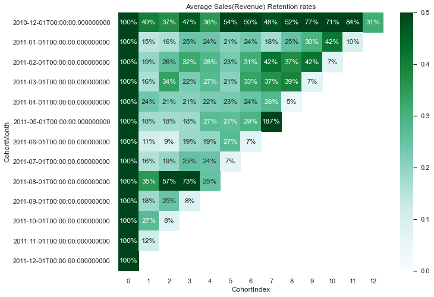

```python
# Drawing a heatmap
plt.figure(figsize=(10, 8))
sns.heatmap(data = retention3, annot = True, fmt = '.0%', vmin = 0.0, vmax = 0.5, cmap = 'BuGn')
plt.title('Average Sales(Revenue) Retention rates')
plt.show()
```

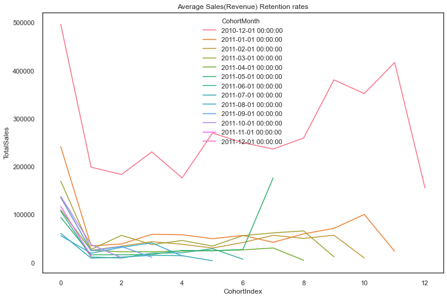

```python
# Drawing a chart
plt.figure(figsize=(12, 8))
ax = sns.lineplot(x="CohortIndex", y="TotalSales", hue= "CohortMonth", data = third_df)
plt.title('Average Sales(Revenue) Retention rates')
ax.legend(loc='upper center', frameon=False)
plt.show()
```

*In the chart above, you can see the retention based on the average revenue in each cohort across the months.*

For e-commerce organisations, cohort analysis is a unique opportunity to find out which clients are the most valuable to their business. by performing Cohort analysis we can get answers to following questions:

- How much effective was a marketing campaign held in a particular time period?
- Did the strategy employed to improve the conversion rates of Customers worked?
- Should I focus more on retention rather than acquiring new customers?
- Are my customer nurturing strategies effective?
- Which marketing channels bring me the best results?
- Is there a seasoanlity pattern in Customer behahiour?

[figure not shown]